# Dose Trajectories of Modern Antipsychotic Programs in Schizophrenia (2009–2026)

Jerry Hu

2026-08-13

← PK/PD Home Page

# 1 Summary

**Background.** Dose selection for a Phase 2 study in a CNS indication — and whether to dose flexibly — is a recurring design decision with sparse prospective evidence. This study reconstructs how completed antipsychotic programs actually chose, tested and revised their doses. For six schizophrenia programs, it traces the tested and recommended dose and schedule from first-in-human through post-marketing, and identifies what data drove each change.

**Methods.** The cohort was defined by rule: every new molecular entity oral antipsychotic FDA-approved for schizophrenia from 2009 onward (8 programs). Six were reconstructed in full. Four met a pre-specified criterion of a dose-related regulatory action or post-approval dose revision (iloperidone, lurasidone, cariprazine, lumateperone); two were chosen as contrasts (ulotaront, a flexible-dose Phase 2 success that failed in fixed-dose Phase 3; xanomeline–trospium, whose label transcribes its titration trial design). Every study and every dose or schedule change was extracted from FDA approval packages, archived labels and publications; each fact carries its source and whether the primary document was read in full. Each study was classified by the dose-related question it was run to answer, and each post-approval label change by the question it resolved. Receptor occupancy was annotated against the 65–80% striatal D2 window.

**Results.** The extraction covers 329 studies and 93 dose or schedule changes, from 146 sources (88% primary documents read in full). Of the 5 approved programs, 4 lowered a wide early ceiling to a narrow registered range, each for a different reason. Iloperidone was capped by QT prolongation under forced titration. Lurasidone took a conservative cap that was later doubled (80 to 160 mg/day (approved 2012-04-26, ~18 months post-launch)). Cariprazine was capped by its metabolite below the demonstrated efficacy range (6 mg/day cap despite efficacy shown at doses up to 9 mg/day). Lumateperone was approved at a single dose well below the D2 window (39% peak D2 occupancy at the approved 42 mg dose). The two novel-mechanism programs had no occupancy anchor at all. Ulotaront’s Phase 3 failure followed a Phase 2 that never explored the upper end of its range (DIAMOND 2 tested a fixed 100 mg/day never given in Phase 2). Across the 194 studies of the six programs, 35 were run to find out *who needs a different dose* (drug interactions, organ impairment, special populations) and 13 to characterise the dose-response relationship. After approval, only 1 of 25 label changes moved the approved dose range.

**Conclusions.** In this cohort, flexible dosing in Phase 2 repeatedly deferred — rather than answered — the dose-response question, and regulators either imposed fixed-dose designs (lurasidone), demanded high-dose safety data (iloperidone), or accepted titration schemes transcribed from flexible-dose trials (xanomeline–trospium). Where titration was obligatory or was itself the intended label, the flexible design was the right instrument; the failure mode is its use as a substitute for dose-finding, since a flexible trial estimates a titration strategy and not the shape of the dose-response curve. Doses left untested in Phase 2 proved close to unrecoverable afterwards. The occupancy playbook that guided the D2 era did not transfer to the newest mechanisms, which leaves fixed-dose Phase 2 dose-ranging as the only remaining place the question can be settled.

# 2 Background

A standard interview question in clinical pharmacology asks: *what are the considerations for dose selection of a Phase 2 study in a central nervous system (CNS) indication — specifically, flexible dosing?* The textbook answer lists dose-response characterization, tolerability-driven titration, and the risk that flexible designs confound dose with patient state. This study asks what the completed record actually shows.

## 2.1 What “the dose-response question” means here

The phrase compresses five distinct questions, which a development programme answers with different designs and at different costs:

1. **Is there a relationship at all** over the range that can be given — or is the drug flat because the tested range already sits on a plateau, or wholly below threshold?
2. **What is the shape** — where the curve rises, where it bends, and whether the top of the tested range is on the flat part. Near-maximal effective doses (ED95) are answers to this question.
3. **What is the safety and tolerability curve** over the same range. This one is generally monotone increasing, so the object of interest is the *joint* behaviour of curves 2 and 3 — the vertical gap between them.
4. **Which dose, and how wide a range**, goes into confirmatory trials and onto the label. A decision derived from 2 and 3, not a separate estimand.
5. **Is the optimum individual or population-level** — does a patient failing at one dose benefit at a higher one, and can that patient be identified prospectively? Titration presumes yes to both.

Question 5 is decisive and rarely examined. Flexible dosing is only rational if individual optima genuinely differ *and* the treating clinician can detect who needs more. In acute schizophrenia, with a four-to-six-week symptom scale as the readout and no pharmacodynamic biomarker at the bedside, the up-titration decision is made on early non-response — a weak predictor of eventual response.

**Four dosing designs** appear in the studies below, and the distinction between them matters for reading everything that follows. *Fixed-dose*: each arm is randomised to one dose held constant. *Flexible-dose*: the clinician adjusts the dose within a range on response and tolerability, so the dose a patient ends on is not randomised. *Forced titration*: every patient climbs a fixed schedule to a fixed target — a design in which schedule and dose are one thing. Forced titration with an *optional* top step (the xanomeline–trospium trials) is coded as flexible in the tables below, because the top dose is reached by a tolerability decision rather than by design. In addition, Phase 1 *dose escalation* and *single-dose* studies are named as such.

A flexible-dose trial delivers a clean randomised estimate of exactly one thing: the effect of *a titration strategy* — start here, escalate by these rules — versus control. That is a legitimate estimand, and it is the right one when the label will itself be a titration. What such a trial cannot deliver is the shape of the dose-response curve, for three structural reasons:

- **Dose is determined by the patient’s response.** The dose a patient ends on is *caused by* their response and tolerability: non-responders are pushed up, responders stay low. The observed dose–outcome association is confounded by prognosis and can come out flat, or inverted, regardless of the truth. Because nothing was randomised to dose, no valid contrast exists to be recovered by adjustment.
- **Dose is confounded with time.** Higher doses occur later, and so do placebo response, spontaneous improvement, and differential dropout.
- **The top of the range is estimated on a selected minority** — the patients tolerant enough to climb — or, as one program in this cohort shows, is never reached at all.

Exposure–response analysis does not repair this when the spread in exposure is generated by titration decisions rather than by pharmacokinetic variability at a fixed dose: exposure then inherits the same dependence on response that dose has. It does retain some value where patients are held at the same step and differ in exposure only through clearance, food or adherence — which is why regulators have accepted such analyses in forced-titration programs. The distinction is applied below to the one program in the cohort that argued its dose case on exposure–response grounds.

## 2.2 Why antipsychotics

Antipsychotics in schizophrenia are a favorable class for this question. The pharmacology has a quantitative spine — striatal D2 receptor occupancy of roughly 65–80% has long been treated as the antipsychotic therapeutic window, with extrapyramidal symptoms (EPS) rising above it — and the modern programs fall entirely inside the ClinicalTrials.gov era. The window itself was established by PET in the 1990s and has since been examined by dose–occupancy meta-analysis (Farde 1992; Kapur 2000; Siafis 2023). The class also spans the question’s extremes: programs that titrated because they had to, programs capped below their own efficacy data, a single-dose approval at 39% occupancy, and two novel mechanisms (a TAAR1 agonist and an M1/M4 muscarinic agonist) for which no occupancy anchor existed.

**Objective.** For six antipsychotic development programs in schizophrenia, reconstruct how the tested and recommended dose level and schedule evolved from first-in-human through post-marketing, identify what data — PK and metabolite behavior, receptor occupancy, tolerability, efficacy, regulatory feedback — drove each change (RQ1), and map the dose-related question each subsequent study was designed to answer (RQ2).

A companion study, How much of a dose trajectory does the registry see?, benchmarks how much of these trajectories is recoverable from the ClinicalTrials.gov footprint alone.

# 3 Methods

## 3.1 Cohort and reconstruction depth

The cohort rule was fixed before extraction: every new molecular entity (NME) oral antipsychotic FDA-approved for schizophrenia in 2009 or later. Eight programs qualify (table below). The qualifying set was assembled by walking the FDA’s own NME approval listings for 2009 onward and keeping the oral antipsychotics with a schizophrenia indication; each survivor is carried in `programs.csv` with its NDA number, so the denominator can be checked against Drugs@FDA rather than taken on trust. It is a small enough set to enumerate exhaustively, which is why no search strategy applies to this step. Aripiprazole (2002) predates the rule and is cited only as background for the partial-agonist programs; long-acting injectable line extensions are recorded as single formulation events, not separate programs.

**Two depths of reconstruction.** Every program below was enumerated the same way — the complete study list from its FDA approval package. Six programs were then reconstructed in full: every dated dose or schedule change, the data behind each change, and the dose question each study answered. The remaining three were left at the study list alone. Depth follows from whether a program has a dose story to reconstruct, not from how much evidence it carries: asenapine contributes the largest study count of any program here and no dose events at all, because its adult-schizophrenia dosing has never changed.

The **six fully reconstructed programs** are five from the cohort plus one outside it. Four met a pre-specified criterion — (a) a dose-related regulatory action, or (b) a post-approval revision of the originally approved adult-schizophrenia dose or administration: iloperidone (2008 not-approvable letter demanding safety data at 20–24 mg/day), lurasidone (2012 maximum-dose doubling), cariprazine (2013 complete response letter for dose-related late-emerging toxicity), and lumateperone (2021 food-requirement removal; 2022 special-population strengths). Two contrast cases were chosen rather than selected by the criterion, because they illustrate the extremes of the flexible-dosing question: xanomeline–trospium, the index case whose label titration transcribes its trial design, and ulotaront — which is *not* a member of the eight-program cohort, having been terminated in Phase 3 without ever reaching approval. That two of the six were chosen for what they illustrate is a selection constraint on the discussion, taken up in the Limitations.

The **three list-only programs** — asenapine, brexpiprazole and olanzapine/samidorphan — received the study enumeration and nothing further. Enumerating them was not incidental: it is what lets the companion recall study’s reference standard cover all eight approved programs rather than the five reconstructed here.

The cohort: NME oral antipsychotics FDA-approved for schizophrenia 2009 or later, plus the failure contrast, ulotaront.

| Program | Mechanism | Sponsor | US approval | Reconstruction | Basis for full reconstruction |
| --- | --- | --- | --- | --- | --- |
| Iloperidone (Fanapt) | D2/5-HT2A antagonist | Hoechst → Novartis → Titan → Vanda | 2009-05-06 | Full (studies + dose/schedule changes) | criterion (a): Jul 2008 not-approvable letter demanding additional safety data at 20-24 mg/day |
| Lurasidone (Latuda) | D2/5-HT2A/5-HT7 antagonist | Dainippon Sumitomo → Sunovion | 2010-10-28 | Full (studies + dose/schedule changes) | criterion (b): May 2012 max dose raised 80 to 160 mg/day |
| Cariprazine (Vraylar) | D2/D3 partial agonist | Gedeon Richter → Forest → Allergan → AbbVie | 2015-09-17 | Full (studies + dose/schedule changes) | criterion (a): Nov 2013 CRL for dose-related late-emerging toxicity (DDCAR accumulation); approved cap 6 mg below demonstrated 9 mg efficacy |
| Lumateperone (Caplyta) | 5-HT2A antagonist / dose-dependent D2 modulator | Intra-Cellular Therapies | 2019-12-20 | Full (studies + dose/schedule changes) | criterion (b): Dec 2021 food requirement dropped; Apr 2022 special-population strengths added |
| Xanomeline/Trospium Chloride (Cobenfy) | M1/M4 muscarinic agonist + peripheral anticholinergic | Karuna Therapeutics → Bristol Myers Squibb | 2024-09-26 | Full (studies + dose/schedule changes) | declared contrast (index case): label titration transcribes the EMERGENT flexible-dose design |
| Ulotaront | TAAR1 agonist (5-HT1A activity) | Sunovion → Sumitomo Pharma → Otsuka | — (terminated) | Full (studies + dose/schedule changes) | declared contrast (failure): flexible-dose Ph2 success then fixed-dose Ph3 collapse incl. an untested dose |
| Asenapine (Saphris) | D2/5-HT2A multireceptor antagonist | Organon → Schering-Plough → Merck | 2009-08-13 | Study list only |  |
| Brexpiprazole (Rexulti) | D2 partial agonist | Otsuka → Lundbeck | 2015-07-10 | Study list only |  |
| Olanzapine/Samidorphan (Lybalvi) | D2/5-HT2A antagonist + mu-opioid antagonist | Alkermes | 2021-05-28 | Study list only |  |

## 3.2 Data sources and extraction

Facts were extracted into four linked tables (studies; dose and schedule changes; sources; occupancy data), each row keyed to a source with a stated verification level: *primary document read in full* (FDA review PDFs, archived DailyMed label versions), *seen only in search snippets*, or *secondary*. Study enumeration used the FDA approval packages, whose clinical-pharmacology reviews list the complete Phase 1 program and whose medical reviews list all controlled trials; post-approval events come from supplemental approvals and the archived label version history. For ulotaront, which has no FDA package, the registry and publications were used instead. The three list-only programs (asenapine, brexpiprazole, olanzapine/samidorphan) received the same FDA-package study enumeration — without reconstruction of their dose changes — so that the companion recall study’s reference standard covers all eight approved programs. 88% of the 146 sources are primary documents read in full.

Two extraction rules protect the companion registry-recall study: trial registry identifiers were recorded only when stated in an FDA document or publication (never looked up in the registry), and registry content was not used to fill study attributes for the approved programs.

**Search and cut-off.** All sources were retrieved and verified on 2026-08-13, which is the data cut-off: label changes, approvals or publications after that date are not represented. The FDA stream is an enumeration rather than a search — for each program the complete approval package and the full archived label version history were read end to end, so no query terms apply. The remaining streams were searched rather than enumerated, and are therefore the components where recall is not guaranteed: publications were located from the reference lists of the FDA reviews and by drug-name searches for PET occupancy and dose-response reports; occupancy values were taken from those publications plus two curated meta-analyses fixed in advance (Siafis 2023, Leucht 2020); and ulotaront, which has no FDA package, was reconstructed from its registry records, sponsor announcements and publications. No database was searched systematically with a recorded Boolean query, so the non-FDA streams are best treated as a purposive sample of the public record rather than an exhaustive one.

Each study row carries the dose-related question it was run to answer, assigned from the study’s position and design in the program (RQ2); inserted special studies — positron emission tomography (PET) occupancy, thorough-QT (TQT), food-effect — are read as markers of a question the program needed answered. Numeric total-daily-dose bounds were curated per study from the arm descriptions, excluding comparator arms.

For the cross-program RQ2 view, each study type was mapped one-to-one onto a question (dose-ranging → *what is the dose-response*; drug-interaction and special-population → *who needs a different dose*; food-effect → *how is the dose given*, since its product is an instruction about taking the dose, not about who takes it; absorption, distribution, metabolism and excretion (ADME) characterization → *how does the body handle the drug*, kept separate because it describes disposition rather than prescribing a different dose to anyone; and so on), so that every study of the six fully reconstructed programs falls in exactly one class. Post-approval events — those dated after a program’s first FDA approval, excluding approvals themselves — were classified in the same spirit by what the label change did: moved the therapeutic range, added strengths within it, altered administration, addressed a subpopulation, or clarified wording. Subpopulation events are further split by whether they dose a schizophrenia patient or carry the molecule into another indication. Both mappings are deterministic functions of the extracted vocabularies, applied in `02-analyze/analyze.R`; neither re-reads sources. They are single-rater classifications: the mapping is the codebook, and no independent coder recoded it.

**Abbreviations in the tables.** The cohort table above and the per-program event and study tables below quote regulatory and clinical-pharmacology shorthand: CRL, complete response letter, and NAL, not-approvable letter (the two forms of FDA refusal in this cohort); EOP2, end-of-Phase-2 meeting; MTD, maximum tolerated dose; SAD and MAD, single- and multiple-ascending-dose studies; DDI, drug–drug interaction; TQT, thorough QT study; ddQTc, the placebo-corrected change from baseline in the QT interval, with the trailing letters naming the heart-rate correction used (F = Fridericia); PET, positron emission tomography; ADME, absorption, distribution, metabolism and excretion; DDCAR, didesmethyl-cariprazine, the long-half-life active metabolite that governs cariprazine’s accumulation; SPL, the structured product label version published on DailyMed; PMC, a post-marketing commitment; and BID, QD and TID for twice-, once- and three-times-daily dosing.

## 3.3 Occupancy annotation

Reported target-occupancy values were collected per drug and dose from PET publications and the curated meta-analytic literature (Siafis 2023 for the dose–occupancy–EPS relationship; Leucht 2020 for near-maximal effective doses, ED95). Each approved dose range was annotated against the 65–80% D2 window; partial agonists (brexpiprazole, cariprazine) are annotated separately since they tolerate near-saturating occupancy. No formal model was fit — the annotation layer is descriptive.

# 4 Results

## 4.1 The shape of six dose trajectories

The figure below is the study’s central display: the total daily dose range each program tested, by development stage, against what was approved and what stands today.

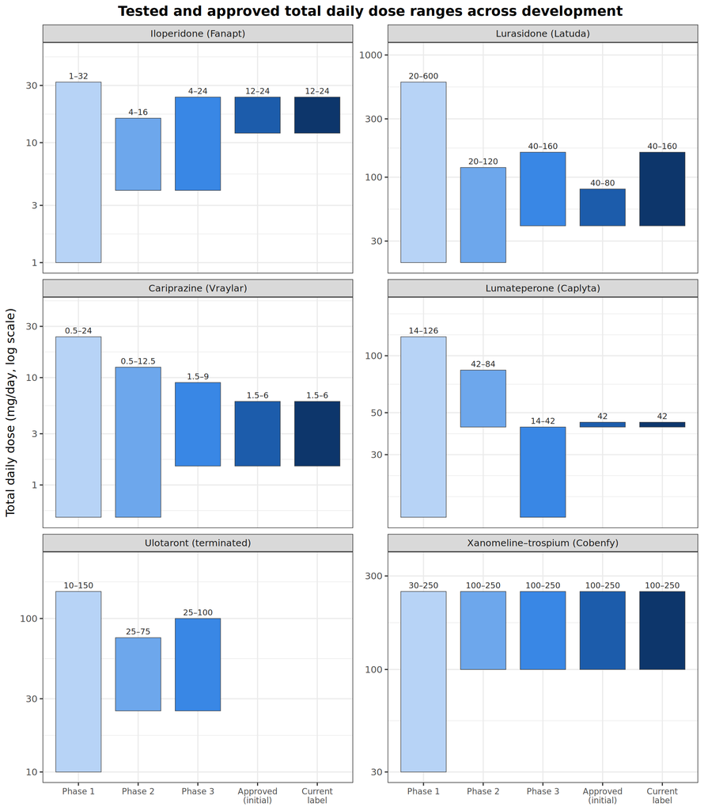

Tested and approved total daily dose ranges by development stage (program drug only; comparator arms excluded). For the Phase 1–3 stages a bar spans the lowest to highest total daily dose *tested* in that stage; for *Approved (initial)* and *Current label* it spans the *labelled* dose range, which is a licensing decision rather than a set of doses studied. Xanomeline–trospium doses are the xanomeline component. Phase 1 includes maximum-tolerated-dose escalations; single-dose approvals draw as slivers.

Four patterns stand out.

- **4 of the 5 reconstructed approved programs lowered their ceiling.** Phase 1 ceilings sat 1.3–7.5-fold above the maximum approved *at registration* (iloperidone 32 vs 24 mg/day; lurasidone 600 vs 80; cariprazine 24 vs 6; lumateperone 126 vs 42). Two cautions on that fold. It is measured against the registration ceiling rather than the current label, which keeps this bullet separate from the re-widening described next. And a Phase 1 ceiling is the highest dose ever *given*, not the highest dose ever considered for therapy: lurasidone’s 600 mg/day comes from a maximum-tolerated-dose escalation and lumateperone’s 126 mg/day is the deliberately supratherapeutic arm of a thorough-QT study, neither of which was ever a candidate dose. The fold therefore measures how far exploration ran above the label, not how much therapeutic range was discarded.
- **Two programs later climbed back up.** Lurasidone’s approved maximum doubled (80 to 160 mg/day (approved 2012-04-26, ~18 months post-launch)); ulotaront’s restart keeps only the top of its range. No new *therapeutic* dose was ever added below an approved range in this cohort — lumateperone’s 10.5 and 21 mg strengths sit below its 42 mg dose but exist only for CYP3A4 inhibition and hepatic impairment.
- **The index case’s ceiling never moved.** Xanomeline–trospium’s Phase 1 ceiling of 250 mg/day is still the label maximum, and it has carried the same 100–250 mg/day titration corridor from Phase 2 to the current label — the range *is* the schedule. (Its floor did rise once, 30 → 100 mg/day between Phase 1 and Phase 2; the ceiling is what never moved.)
- **The failure case widened at the top, into untested ground.** Ulotaront’s controlled Phase 2 tested 50–75 mg/day flexibly; the fixed-dose Phase 3 trials then ran 50–100 mg/day — the 100 mg dose one no Phase 2 study had given. (Both bars in the dose-range figure start at 25 mg/day because each aggregates a long-term flexible study in stable patients that allowed 25 mg — `SEP361-202` in Phase 2 and `SEP361-303` in Phase 3. The controlled trials’ ranges are the ones quoted here.)

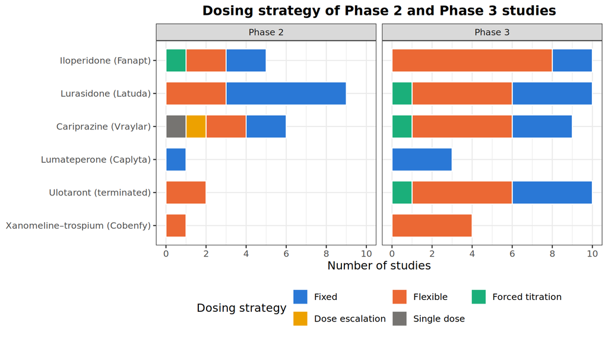

Dosing design of the Phase 2 and Phase 3 studies in the six fully reconstructed programs (count of studies per design; definitions in the Background).

The multiplicity of contrasts across programs and phases in this section is read descriptively — as ranges characterizing the class, not as tests.

## 4.2 What each study was run to answer (RQ2)

Classifying every study of the six fully reconstructed programs by the dose-related question it answered gives the cohort’s answer to RQ2 in one view.

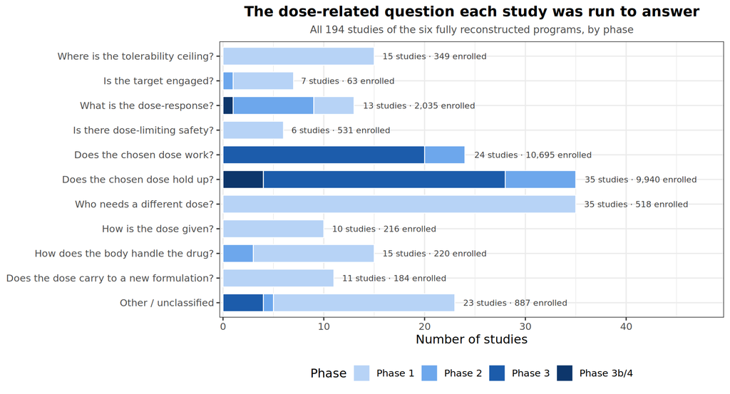

The dose-related question each study was run to answer, across the six fully reconstructed programs. One question per study, assigned from its study type; bars are counts, the annotation also gives total enrolment. Enrolment counts *subjects*, not patients: the who-needs-a-different-dose class is mostly healthy-volunteer and organ-impairment studies, and only 8 of its 35 studies enrol schizophrenia patients. Enrolment is also under-counted for the early-phase classes (not stated in FDA reviews for 55 of 194 studies, 51 of them Phase 1), so every total is a lower bound and should be compared within, not across, phase profiles.

The asymmetry is the finding. Of the 194 studies, a total of 35 asked **who needs a different dose** — drug-interaction and special-population studies — and a further 10 asked how the dose is given (food effect). Only 13 asked **what the dose-response relationship is**, 8 of them in Phase 2. The dose-response studies enrolled more subjects: 2,035 in the 10 of 13 that report enrolment, against at least 518 in 17 of the 35 dose-adjustment studies. That follows from phase rather than contradicting the count: the dose-response studies are mostly Phase 2 patient trials, while the dose-adjustment studies are all Phase 1 and mostly in healthy volunteers. Subject numbers and question frequency measure different things, and the count is the quantity reported here. Dose-adjustment questions are individually cheap, regulatorily obligatory, and answerable in healthy volunteers. The dose-response question is expensive, discretionary, and answerable only in patients. The cohort’s effort follows that cost gradient rather than the question’s importance to the label.

The same asymmetry appears after approval. Of the 25 dated post-approval events across the 5 reconstructed programs that reached approval, 1 changed the approved therapeutic dose range — lurasidone’s 2012 doubling. This denominator counts the reconstructed programs only, not all 8 approved programs in the cohort: the three list-only programs were enumerated but their label changes were never reconstructed, so their label activity is outside these totals. Their adult-schizophrenia dosing has not changed, but that is a statement from the current label rather than a count of events.

Post-approval label activity by the question the change answered, across the 5 fully reconstructed programs that reached approval. “New strengths” are tablet presentations that did not move the approved range. Approvals themselves are excluded (they are not label activity). “Who needs a different dose” is split by scope, because dosing the molecule in another disease is a different claim from adjusting the dose in schizophrenia.

| What the label change answered | Events | Programs |
| --- | --- | --- |
| Therapeutic dose range changed | 1 | Lurasidone |
| New strengths (range unchanged) | 3 | Cariprazine, Lurasidone |
| How the dose is given | 2 | Cariprazine, Lumateperone |
| Who needs a different dose — schizophrenia | 6 | Cariprazine, Iloperidone, Lumateperone, Lurasidone |
| Who needs a different dose — other indication | 6 | Cariprazine, Iloperidone, Lumateperone, Lurasidone |
| Formulation / presentation | 2 | Iloperidone |
| Label clarification | 5 | Iloperidone, Lumateperone, Xanomeline-Trospium |
| Other regulatory | 0 | — |

Post-approval label activity is dominated by 12 changes answering *who needs a different dose*. Only 6 of them adjust the dose for a schizophrenia patient (CYP2D6 poor-metabolizer and hepatic dosing, adolescent dosing, interaction-driven adjustments); the other 6 carry the molecule into a different disease, which is dose work in the label but not in this cohort’s indication. Only 2 changes altered *how* the dose is given (lumateperone’s food requirement, cariprazine’s interaction-driven frequency change). The dose level itself, once registered, is close to immovable. The one range change in this cohort did not need new trials: the decisive 80-versus-160 mg comparison (`lurasidone-S46`) had completed in June 2010, four months *before* the October 2010 approval that capped the range at 80. The eighteen months after approval bought a successful re-argument of data the agency already held, not new data.

## 4.3 Program trajectories

Each tab gives the program’s dose story: the dated dose and schedule changes, and the dose-related question each key study answered. Every timeline is drawn between the same two anchors — the first-in-human date (or, where the record does not give it, the earliest dated human-program milestone, named as such) and the first FDA approval — both marked as dashed lines and repeated in the anchor line under each figure. Two programs (iloperidone, cariprazine) have no first-in-human date in the sources used; their timelines say so.

Program anchors: first-in-human date (or the earliest dated human-program milestone the record supports, stated as such) and first FDA approval, as recorded in the dose and schedule change tables.

| Program | First-in-human (or earliest dated anchor) | First FDA approval |
| --- | --- | --- |
| Cariprazine (Vraylar) | Not dated in the FDA review (Study RGH-188-001, single ascending doses in 40 healthy males, under IND 71,958). Phase 2 (RGH-MD-03) began 2006-11-27. | 2015-09-17 — Approved: schizophrenia 1.5-6 mg QD with or without food; start 1.5 mg, may increase to 3 mg on Day 2; further adjustments in 1.5/3 mg increments; no mandatory titration (bipolar mania 3-… |
| Iloperidone (Fanapt) | Not dated in the FDA review (scanned documents). Hoechst-Roussel Phase 2 was under way by 1996; Novartis Phase 3 began 1998. | 2009-05-06 — NDA 22-192 approved: 12-24 mg/day (6-12 mg BID), max 24 mg/day, without regard to meals, not recommended in hepatic impairment; PMRs (P95 carcinogenicity, P-gp in vitro, repeat hepatic st… |
| Lumateperone (Caplyta) | 2007-11-15 — IND 079690 first clinical trial (open-label receptor-occupancy study) allowed to proceed 2007-11-15 | 2019-12-20 — Single approved dose 42 mg QD, no titration; single 42 mg strength marketed |
| Lurasidone (Latuda) | 2000-11 (month) — US IND 61,292 filed November 2000 (Dainippon Pharma America). The Japanese first-in-human study (SM-071019) predates it and is undated in the FDA review. | 2010-10-28 — Approved: start 40 mg QD, no initial titration, max 80 mg/day, with food (>=350 cal); first review cycle, no advisory committee |
| Ulotaront (terminated) | 2013-08 (month) — SEP361-105 single-ascending-dose study (25-150 mg) in adults with schizophrenia, started 2013-08 (NCT01940159) | — (not approved) |
| Xanomeline–trospium (Cobenfy) | 2017-04-18 — KAR-002, first Karuna Phase 1 of the xanomeline-trospium combination, started 2017-04-18 | 2024-09-26 — NDA 216158 approved: 50/20 mg BID >=2 days, then 100/20 mg BID >=5 days, optional increase to 125/30 mg BID by tolerability/response; max 125/30 mg BID |

### 4.3.1 Iloperidone

The case where titration was obligatory. Iloperidone’s α1-adrenergic orthostasis requires a week-long up-titration from 1 mg twice daily (BID) — the label itself warns that effectiveness is delayed 1–2 weeks — and QTc prolongation (+9 ms at 12 mg BID) caps the range at 24 mg/day. This is the cohort’s legitimate use of a titrated design: a fixed high-dose arm here would have measured syncope rather than efficacy, so titration protected the trials’ ability to detect an effect at all. The cost is that the range is not separable from the schedule — what “24 mg/day” means is inseparable from the week it takes to reach. The 2008 not-approvable letter is the cohort’s clearest regulatory dose demand: an additional trial plus safety data specifically at 20–24 mg/day. The dose range approved in 2009 (12–24 mg/day) has not moved in 17 years; what has moved is everything around it — a CYP2D6 poor-metabolizer halving (2010), a formalized day-by-day titration table and marketed titration packs (2024–2025), and a 2026 successor molecule (milsaperidone) inheriting the franchise. Notably, no human PET dose–occupancy study of iloperidone was identified — the range was set entirely by tolerability and QT.

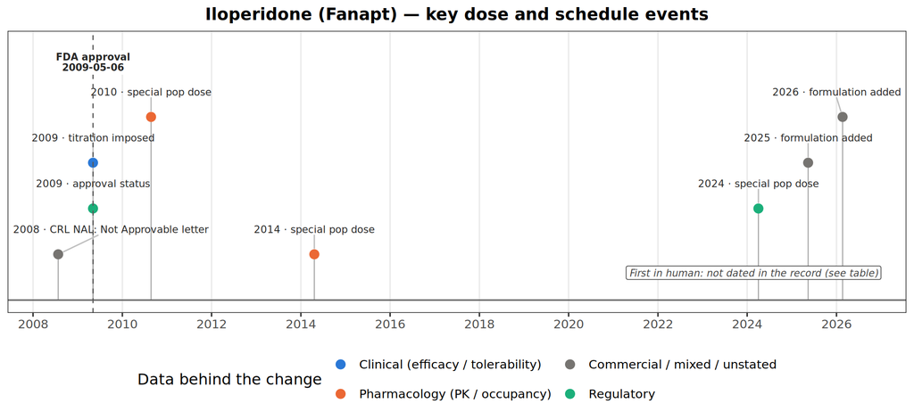

Iloperidone — dated dose and schedule changes, colored by the data family behind each change; dashed lines mark the first-in-human anchor (or the earliest dated human-program milestone, labelled as such) and the first FDA approval. The figure shows dated changes of the key types only; routine range-tested rows, label clarifications, and any change the record leaves undated are omitted here but are listed in full in the table below, which is why the table carries more rows than the figure has points.

**Anchors.** First in human: Not dated in the FDA review (scanned documents). Hoechst-Roussel Phase 2 was under way by 1996; Novartis Phase 3 began 1998. First FDA approval: 2009-05-06 — NDA 22-192 approved: 12-24 mg/day (6-12 mg BID), max 24 mg/day, without regard to meals, not recommended in hepatic impairment; PMRs (P95 carcinogenicity, P-gp in vitro, repeat hepatic study) + PMC (randomized-withdrawal maintenance trial).

Dated dose and schedule changes — Iloperidone (Fanapt).

| Date | Event | Attribute | From | To | Driver | Detail |
| --- | --- | --- | --- | --- | --- | --- |
| 2001-11-01 | range tested | Max daily dose | 24 mg/day development ceiling | FDA Pre-NDA advice to explore doses higher than 24 mg and characterize QT over the whole range; sponsor kept the 24 mg/day cap | Regulatory | Pre-NDA meeting 2001-11-01: FDA recommended exploring >24 mg and higher+lower QT dose groups; 2002-11-07 EOP2 agreed to collect PK at 30-32 mg to bracket the inhibited-24-mg exposure instead |
| 2005-09-07 | range tested | Confirmatory dose selection | dose-response unresolved after wave-1 Phase 3 | single fixed 24 mg/day arm chosen for confirmatory Study 3101 despite FDA advice to include several fixed doses | Regulatory | EOP2 meeting 2005-09-07: FDA said dose response for efficacy was not clarified and recommended several fixed doses; Vanda ran 24 mg/day only, leaving the low end of the range supported mainly by Study… |
| 2008-07-25 | CRL NAL | Approval status | NDA under review (proposed 12-24 mg/day) | Not Approvable letter | Mixed | Two deficiencies: insufficient effectiveness evidence (only 3101 unambiguously positive; iloperidone appeared inferior to risperidone/haloperidol) and insufficient safety exposure at 20-24 mg/day, whi… |
| 2009-03-27 | range tested | Effective dose range | 20-24 mg/day (FDA’s NAL-era position on the only acceptable range) | 12-24 mg/day accepted with target 12 mg/day, without a new trial | Mixed | On re-review of the 2008-11-06 complete response, FDA accepted Study 3005’s schizophrenia-subgroup result as a second positive study; 12 mg/day target supported by modal maintenance dose and sponsor P… |
| 2009-05-06 | approval | Approval status | Not Approvable (2008-07-25) | NDA 22-192 approved: 12-24 mg/day (6-12 mg BID), max 24 mg/day, without regard to meals, not recommended in hepatic impairment; PMRs (P95 carcinogenicity, P-gp in vitro, repeat hepatic study) + PMC (r… | Regulatory | Approval letter signed 2009-05-06; strengths 1/2/4/6/8/10/12 mg; acute-treatment indication only |
| 2009-05-06 | titration imposed | Titration | (none - new label) | mandatory 7-day forced titration: 1 mg BID start, then 2/4/6/8/10/12 mg BID on days 2-7 to reach 6-12 mg BID; label warns symptom control delayed 1-2 weeks vs drugs not needing titration | Tolerability | Slow titration required to avoid orthostatic hypotension and syncope from alpha-1 blockade; more rapid titration expected to increase orthostasis |
| 2010-08-24 | special pop dose | CYP2D6 PM dose | halving directive in section 2.2 only for strong CYP2D6/3A4 inhibitors; PM PK described in 12.3 without dose directive | ‘FANAPT dose should be reduced by one-half for poor metabolizers of CYP2D6’ added to section 2.2 (S-001; label Revised 08/2010) | PK / metabolite | PM exposure higher (parent AUC +47%, active metabolite P88 +85% in ILO5220104); PMs also have longer half-lives (33 vs 18 h parent) and higher QT-relevant exposure |
| 2011-03-21 | label clarification | Indication wording | ‘acute treatment of adults with schizophrenia’ | ‘treatment of adults with schizophrenia’ (‘acute’ removed; S-004, prior-approval labeling supplement by Novartis) | Regulatory | Indication wording broadened; dose range and schedule unchanged |
| 2014-04-21 | special pop dose | Hepatic impairment dosing | ‘FANAPT is not recommended for patients with hepatic impairment’ | mild: no dose adjustment; moderate: exercise caution; severe: not recommended (S-013; label Revised 4/2014) | PK / metabolite | Repeat hepatic-impairment study (2009 PMR #5, redoing inconclusive ILO5220103) enabled graded recommendations |
| 2016-05-26 | label clarification | Maintenance evidence | section 2.3: ‘no body of evidence available’ on treatment duration | section 2.3/14: effective in delaying time to relapse at 8-24 mg/day (randomized-withdrawal trial, n=303, stopped early for efficacy; S-015 efficacy supplement, label Revised 5/2016) | Efficacy / dose-response | Fulfilled the 2009 approval PMC #6 (randomized-withdrawal long-term efficacy trial); maintenance uses the same 12-24 mg/day range - no dose change |
| 2024-04-02 | special pop dose | Other indication titration | schizophrenia-only label, 7-day titration to 6-12 mg BID | bipolar I acute manic/mixed episodes indication added (S-023) with a different, faster titration: 1/3/6/9/12 mg BID on days 1-5, recommended 12 mg BID - FLAG ONLY, different indication; schizophrenia … | Regulatory | Separate indication with its own titration schedule (later marketed as Titration Pack B); recorded as a one-line out-of-scope flag, not part of the schizophrenia trajectory |
| 2024-04-02 | label clarification | Dosing section format | prose dosing instructions (2.1 Usual Dose) with narrative titration sentence | dosing restructured into day-by-day titration Table 1 per indication, plus dedicated CYP2D6-PM subsection 2.2 with its own halved titration table (SPL v26, Revised 4/2024) | Regulatory | Formalization only - numeric schizophrenia titration steps and 6-12 mg BID target identical to 2009; refutes an intervening titration-table change around 2016 |
| 2025-05-14 | formulation added | Packaging | bottles of 1-12 mg tablets | Titration Pack kit presentations added to the SPL (Pack A = schizophrenia 7-day schedule; Pack B = bipolar 5-day schedule); packs named inside dosage Table 1 by the 5/2026 revision | Commercial | Kit SPL (v33, Revised 5/2025) operationalizes the forced titration commercially; no dose or schedule change |
| 2026-02-20 | formulation added | Successor molecule | Fanapt (iloperidone) franchise | Bysanti (milsaperidone) NDA 220358 approved for schizophrenia and bipolar I acute manic/mixed in adults - trajectory tail event: the NCE is iloperidone’s major active metabolite (P88) | Mixed | Lifecycle switch to the active metabolite (press: commercial availability anticipated Q3 2026); metabolite relationship stated in press release and consistent with P88’s active-metabolite role in the … |
| — | range tested | Single dose range | — | 1-5 mg single doses (FIH SAD, ILPB101/101A) | Tolerability | First-in-human single-dose range set very low; hypotension liability of alpha-1 blockade shaped all later dosing |
| — | range tested | Max tolerated dose | 1-5 mg single doses | MAD to 8 mg BID (ILPB200/201); MTD titration to 32 mg/day over 29 days, 24 mg/day over 11-18 days (ILPB203) | Tolerability | Multiple-dose escalation established that doses above the eventual 24 mg/day cap (up to 32 mg/day) were reachable only with prolonged titration |
| — | titration imposed | Titration | start-at-target dosing | mandatory slow uptitration in every patient (e.g. 2/4/8/12 mg/day on days 1-4 in Study 3005) | Tolerability | Orthostatic hypotension from alpha-1-adrenergic blockade forced slow titration into all Phase 2/3 protocols; slower titration than comparators later blamed for apparent early inferiority vs risperidon… |
| — | range tested | Phase 2 dose range | MAD range 2-16 mg/day | Phase 2 efficacy tested at 4-8 mg/day fixed (ILPB202), up to 16 mg/day flexible (ILPB205), 8 mg/day QD vs BID (ILPB303), 12 mg/day titration/frequency (ILP2001ST) | Efficacy / dose-response | Low-dose Phase 2 exploration; QD regimens tested but program settled on BID dosing |
| — | range tested | Phase 3 dose range | Phase 2 range 4-16 mg/day | Phase 3 wave 1 tested 4-24 mg/day: fixed 4/8/12 mg/day (3000), flexible 4-8 and 10-16 mg/day (3004), flexible 12-16 and 20-24 mg/day (3005), maintenance 4-16 mg/day (3001/3002/3003) | Efficacy / dose-response | Novartis-era Phase 3 program walked the range upward across nonoverlapping flexible ranges after low fixed doses (4-8 mg/day) underperformed |
| — | formulation added | Formulation | oral IR tablets | IM depot variants tested at single/multiple doses up to 750 mg (ILO522B210); depot never approved | Not stated | Depot line explored during Novartis era in patients tolerating oral iloperidone; no US depot approval through 2026 |
| — | first in human | First clinical study | — | Not dated in the FDA review (scanned documents). Hoechst-Roussel Phase 2 was under way by 1996; Novartis Phase 3 began 1998. | Not stated | First-in-human date not recoverable from the sources used; program chronology bounded by the licensing history in the secondary literature. |

The dose-related question each key study answered — Iloperidone (Fanapt).

| Phase | Study type | Study | Dosing design | Question the study answered |
| --- | --- | --- | --- | --- |
| 1 | First-in-human (SAD/MAD) | ILPB101/101A | Dose escalation | What single oral doses of iloperidone are safe and tolerable in humans (first-in-human SAD)? |
| 1 | Food effect | ILPB103 | Single dose | Does food alter the PK of a 3 mg dose (early food-effect assessment)? |
| 1 | Food effect | ILO5220105 | Single dose | Does food affect iloperidone absorption and what is the tablet’s relative bioavailability vs oral solution (result: no food effect; ~96% relative BA)? |
| 1 | Dose-ranging | ILPB203 | Dose escalation | What is the maximum tolerated dose and how fast can iloperidone be titrated in patients (MTD bridging; explored above the eventual 24 mg/day cap)? |
| 1 | First-in-human (SAD/MAD) | ILPB200 | Dose escalation | Are multiple low doses (1-4 mg BID) safe and tolerable in patients (first MAD)? |
| 1 | First-in-human (SAD/MAD) | ILPB201 | Dose escalation | Are multiple doses up to 8 mg BID safe with acceptable PK in patients (MAD extension of the range)? |
| 1 | Thorough QT | ILO5222328 | Fixed | How much does iloperidone prolong QTc across the dose range and under CYP2D6/3A4 inhibition (QTcF +9 ms at 12 mg BID; ~+19 ms under dual inhibition) - the finding that caps the dose range? |
| 2 | Dose-ranging | ILPB202 | Fixed | Is low-dose iloperidone (4-8 mg/day) efficacious over 4 weeks (Phase 2 low-range exploration)? |
| 2 | Dose-ranging | ILPB205 | Flexible | Pilot signal-seeking: is up to 16 mg/day efficacious over 42 days? |
| 2 | Dose-ranging | ILPB303 | Fixed | Are 8 mg/day regimens efficacious and is QD dosing viable vs BID (frequency question; program stayed BID)? |
| 2 | Dose-ranging | ILP2001ST | Forced titration | How fast can iloperidone be titrated to 12 mg/day and does QD equal BID at the same total dose (titration-rate and frequency question)? |
| 3 | Pivotal efficacy | ILP3000ST | Fixed | Which fixed dose 4-12 mg/day beats placebo over 6 weeks (FDA: negative; 8+12 primary contrast p=0.148 schizophrenia subgroup, p=0.065 all patients; haloperidol superior)? |
| 3 | Pivotal efficacy | ILP3004ST | Flexible | Are nonoverlapping flexible ranges 4-8 and 10-16 mg/day efficacious (all-patients analysis positive but schizoaffective-driven; FDA judged uninterpretable; risperidone superior to both ranges)? |
| 3 | Pivotal efficacy | ILP3005ST | Flexible | Are the higher nonoverlapping ranges 12-16 and 20-24 mg/day efficacious (both positive in schizophrenia subgroup; risperidone superior at 12-16, p=0.005; became FDA’s second positive study on re-revie… |
| 3 | Pivotal efficacy | VP-VYV-683-3101 | Fixed | Is fixed 24 mg/day efficacious over 4 weeks in schizophrenia-only US/India population (the program’s only unambiguously positive study; run after FDA’s 2001 demand for another positive trial; FDA’s 20… |
| 3b/4 | Relapse prevention | — | Flexible | Does continued iloperidone 8-24 mg/day delay relapse vs withdrawal to placebo (yes; stopped early for efficacy at interim; fulfilled the 2009 approval PMC and added the maintenance claim to the label … |

### 4.3.2 Lurasidone

The regulator-shaped trajectory. At the end-of-Phase-2 meeting the FDA rejected the sponsor’s *flexible-dose* Phase 3 proposal and required fixed doses — the cohort’s most direct regulatory verdict on flexible dosing. A 20 mg dose was dropped on PET occupancy (51–54.8%, below the window) combined with its Phase 2 efficacy data, not on occupancy alone. Approval (2010) capped the range at 80 mg/day, reading the dose-response as flat above 80 with dose-related akathisia (5.6% at 20 mg rising to 22% at 120 mg) — a cap below the demonstrated efficacy range, since 120 mg had shown efficacy. Eighteen months later the sponsor won the cap back: five short-term studies, including a direct 80-vs-160 comparison, supported doubling the maximum to 160 mg/day (April 2012). The ≥350 kcal food requirement has never moved. The EU label (2014) admits the full 37–148 mg range that the initial US label had cut in half.

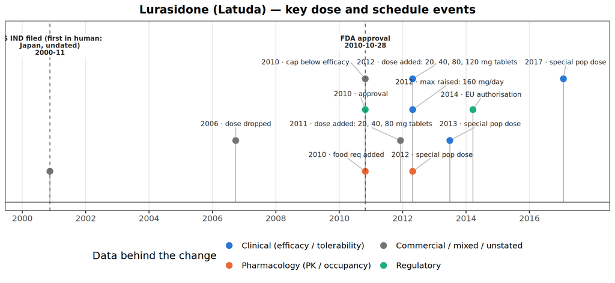

Lurasidone — dated dose and schedule changes, colored by the data family behind each change; dashed lines mark the first-in-human anchor (or the earliest dated human-program milestone, labelled as such) and the first FDA approval. The figure shows dated changes of the key types only; routine range-tested rows, label clarifications, and any change the record leaves undated are omitted here but are listed in full in the table below, which is why the table carries more rows than the figure has points.

**Anchors.** First in human: 2000-11 (month) — US IND 61,292 filed November 2000 (Dainippon Pharma America). The Japanese first-in-human study (SM-071019) predates it and is undated in the FDA review. First FDA approval: 2010-10-28 — Approved: start 40 mg QD, no initial titration, max 80 mg/day, with food (>=350 cal); first review cycle, no advisory committee.

Dated dose and schedule changes — Lurasidone (Latuda).

[output not shown]

The dose-related question each key study answered — Lurasidone (Latuda).

| Phase | Study type | Study | Dosing design | Question the study answered |
| --- | --- | --- | --- | --- |
| 1 | First-in-human (SAD/MAD) | SM-071019 | Dose escalation | What single doses of lurasidone are tolerated in humans (Japanese first-in-human SAD)? |
| 1 | First-in-human (SAD/MAD) | S01P13 | Fixed | Are multiple doses tolerated and what is the multiple-dose PK (Japanese MAD)? |
| 1 | Food effect | S01P12 | Single dose | Does food change lurasidone exposure (first food-effect assessment)? |
| 1 | First-in-human (SAD/MAD) | D1050001 | Dose escalation | What single doses 10-100 mg are tolerated in US healthy volunteers and what is the single-dose PK? |
| 1 | First-in-human (SAD/MAD) | D1050002 | Fixed | Are 40 and 80 mg/day tolerated at steady state (US MAD)? |
| 1 | PET receptor occupancy | D1050180 | Single dose | What D2 receptor occupancy do 10-80 mg single doses produce (basis, with Phase 2 data, for dropping 20 mg: 51-54.8% at 20 mg vs 63.1-67.5% at 40 mg)? |
| 1b | Dose-ranging | D1050160 | Dose escalation | What is the maximum tolerated dose above 120 mg/day in patients? |
| 1b | Dose-ranging | D1050217 | Dose escalation | How high can dosing go: tolerability of 160-600 mg/day in patients (supported TQT supratherapeutic dose)? |
| 1b | Thorough QT | D1050249 | Fixed | Does lurasidone prolong QTc at therapeutic (120 mg) and supratherapeutic (600 mg) doses? (7.5 ms at 120 mg, 4.6 ms at 600 mg; negative per FDA) |
| 1b | Food effect | D1050267 | Fixed | How do meal size and fat content affect exposure (basis for the ‘with food, >=350 calories’ rule; exposure flat from 350 to 1000 cal)? |
| 2 | Dose-ranging | D1001001 | Fixed | Which of 20/40/80 mg/day shows efficacy in Japanese patients (no placebo arm)? |
| 2 | Pivotal efficacy | D1050006 | Fixed | Are 40 and 120 mg/day superior to placebo (first US placebo-controlled efficacy trial)? |
| 2 | Dose-ranging | D1050049 | Fixed | Which of 20/40/80 mg/day separates from placebo? (failed trial: no arm, including haloperidol, separated) |
| 2 | Pivotal efficacy | D1050196 | Fixed | Is 80 mg/day superior to placebo? |
| 3 | Pivotal efficacy | D1050229 | Fixed | Does the full proposed dose range 40/80/120 mg/day separate from placebo in one trial (per EOP2 agreement)? Only 80 mg did overall; all doses positive at non-US sites |
| 3 | Pivotal efficacy | D1050231 | Fixed | Are 40 and 120 mg/day superior to placebo with assay sensitivity (olanzapine arm)? Both positive; 120 no better than 40 |
| 3 | Pivotal efficacy | D1050233 | Fixed | Is 160 mg/day effective and tolerable vs 80 mg/day (the direct 80-vs-160 comparison that supported the 2012 max-dose increase)? |
| 3 | Pivotal efficacy | D1001002 | Fixed | Do 40 and 80 mg/day separate from placebo in East Asian patients (Japan/Korea/Taiwan, non-IND)? |
| 3b/4 | Maintenance / withdrawal | — | Flexible | Does lurasidone maintain efficacy / delay relapse after stabilization (randomized-withdrawal design specified by FDA PMC 1701-3)? Relapse risk reduced 33.7% |
| 3b/4 | Dose-ranging | — | Fixed | Is 20 mg/day effective (FDA PMC 1701-4 lower-dose question: no, 20 mg not superior to placebo) and does escalation to 160 mg/day help early nonresponders (yes)? |

### 4.3.3 Cariprazine

The metabolite-driven trajectory — the strongest pre-approval dose story in the cohort. Cariprazine’s didesmethyl metabolite (DDCAR) has a 2–3 week half-life and accumulates ~25-fold between day 1 and day 14, approaching steady state only at weeks 4–6 — after the acute trials ended. The 2013 complete response letter was explicitly about this: late-emerging akathisia/EPS tracking a poorly characterized metabolite. The 2015 approval then capped the range at 6 mg/day despite efficacy demonstrated up to 9 mg (and Phase 2 run to 12.5 mg, Phase 1b to 24), because 6 mg carried roughly twice the akathisia of 3 mg. The label carries unique kinetic language — “changes in dose will not be fully reflected in plasma for several weeks” — and a Late-Occurring Adverse Reactions warning. The FDA asked for lower or less-frequent maintenance dosing to be evaluated; a dose-reduction relapse-prevention trial was run, but through the end of 2025 no label change has followed — the lower-maintenance-dose question remains open a decade after it was posed.

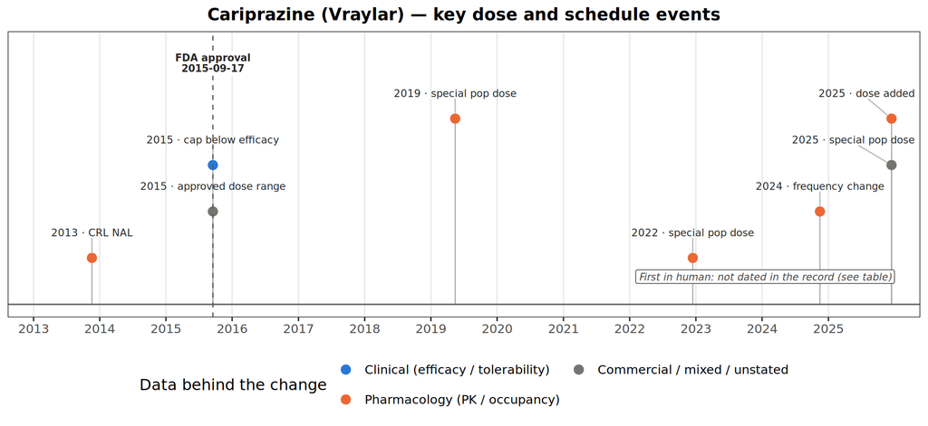

Cariprazine — dated dose and schedule changes, colored by the data family behind each change; dashed lines mark the first-in-human anchor (or the earliest dated human-program milestone, labelled as such) and the first FDA approval. The figure shows dated changes of the key types only; routine range-tested rows, label clarifications, and any change the record leaves undated are omitted here but are listed in full in the table below, which is why the table carries more rows than the figure has points.

**Anchors.** First in human: Not dated in the FDA review (Study RGH-188-001, single ascending doses in 40 healthy males, under IND 71,958). Phase 2 (RGH-MD-03) began 2006-11-27. First FDA approval: 2015-09-17 — Approved: schizophrenia 1.5-6 mg QD with or without food; start 1.5 mg, may increase to 3 mg on Day 2; further adjustments in 1.5/3 mg increments; no mandatory titration (bipolar mania 3-6 mg co-approved).

Dated dose and schedule changes — Cariprazine (Vraylar).

| Date | Event | Attribute | From | To | Driver | Detail |
| --- | --- | --- | --- | --- | --- | --- |
| 2006-11-27 | range tested | Phase 2 dose range | Phase 1 explored 0.5-24 mg/day | Two flexible ranges tested in acute schizophrenia: 1.5-4.5 and 6-12 mg/day (RGH-MD-03) | Not stated | Proof-of-concept bracketed a low and a high flexible range; most patients were titrated to the top of their range (4.5 / 12 mg), so the trial effectively compared 4.5 vs 11-12 mg/day. |
| 2008-06 | range tested | Phase 3 dose range | Phase 2 flexible ranges 1.5-4.5 and 6-12 mg/day | Phase 3 fixed / fixed-flexible 1.5-9 mg/day: 1.5/3/4.5 fixed (RGH-MD-16, from 2008-06); 3/6 fixed (RGH-MD-04) and 3-6/6-9 flexible (RGH-MD-05) (from 2010-04) | Efficacy / dose-response | MD-03’s low range was significant but its high range was not (LOCF) with dose-related EPS - the 12 mg top was dropped and Phase 3 pivoted to discrete fixed doses no higher than 9 mg/day to characteriz… |
| 2013-11-19 | CRL NAL | Approvability (dose-related toxicity) | NDA 204370 submitted 2012-11-19 (schizophrenia + bipolar mania) | Complete Response Letter citing significant dose-related toxicities | PK / metabolite | Late-emerging akathisia/EPS increased through weeks 4-6 of the 6-week trials as DDCAR (t½ 2-3 weeks; ~25-fold total-exposure accumulation Day 1 to Day 14) approached steady state; FDA judged the DDCAR… |
| 2015-09-17 | approval | Approved dose range | Complete Response (2013-11-19); class-2 resubmission 2014-12-17 with new DDCAR PK from A002-A11 and RGH-MD-06 | Approved: schizophrenia 1.5-6 mg QD with or without food; start 1.5 mg, may increase to 3 mg on Day 2; further adjustments in 1.5/3 mg increments; no mandatory titration (bipolar mania 3-6 mg co-appro… | Mixed | Resubmission PK (12 wks on / 12-14 wks off drug) let FDA describe DDCAR accumulation and washout in labeling; approval carried PMRs 2947-9/-10 (randomized-withdrawal multi-dose maintenance trials incl… |
| 2015-09-17 | cap below efficacy | Max daily dose | Efficacy demonstrated 1.5-9 mg/day (RGH-MD-05 6-9 mg arm positive, mean dose 8.39 mg; trials ran to 12 mg/day) | Maximum recommended dose 6 mg/day | Tolerability | Dose-related akathisia/EPS: in RGH-MD-04 the 6 mg arm had twice the akathisia-related events of the 3 mg arm, with new late-onset cases through trial end; label states doses above 6 mg do not confer i… |
| 2015-09-17 | label clarification | PK-accumulation labeling | — | Unique 2.1 language: ‘changes in dose will not be fully reflected in plasma for several weeks’; new Warnings & Precautions 5.5 ‘Late-Occurring Adverse Reactions’; 2.5 notes 50% decline ~1 week after d… | PK / metabolite | Summary Review: clinicians must understand DDCAR accumulation drives efficacy and adverse reactions after ~1 week and rises for perhaps 4-8 weeks; monitoring for several weeks after each dosage change… |
| 2019-05 | special pop dose | Other-indication dosing (bipolar depression) | — | Bipolar I depression added: 1.5-3 mg QD, increase to 3 mg no earlier than Day 15, max 3 mg/day (adult schizophrenia dosing unchanged) | PK / metabolite | Flagged one-line event (other indication): the mandated >=14-day titration interval reflects slow active-moiety accumulation - label notes titration at <14-day intervals produced more adverse reaction… |
| 2022-12 | special pop dose | Other-indication dosing (MDD adjunct) | — | Adjunctive MDD added: 1.5 mg QD, may increase to 3 mg on Day 15, max 3 mg/day (adult schizophrenia dosing unchanged) | PK / metabolite | Flagged one-line event (other indication): same Day-15, max-3-mg pattern as bipolar depression, again encoding the multi-week accumulation kinetics into titration pace. |
| 2024-11 | frequency change | CYP3A4-inhibitor co-administration dosing | 2015-2024: strong CYP3A4 inhibitor -> halve dose (1.5 mg patients -> every-other-day); no moderate-inhibitor dose modification (still absent in v24, Revised 2/2024) | Revised 11/2024 (SPL v26): tabulated schedules - strong inhibitor: 1.5 mg every 3 days (patients on 1.5/3 mg) or every other day (4.5/6 mg); moderate inhibitor: 1.5 mg every other day or once daily; i… | PK / metabolite | With only a 1.5 mg minimum strength, the multi-week effective half-life of the active moiety was managed by stretching the dosing interval rather than lowering the dose; first-ever moderate-inhibitor … |
| 2025-12 | special pop dose | Pediatric dosing (schizophrenia 13-17; bipolar mania 10-17) | Adults only | Pediatric schizophrenia 13-17: start 0.5 mg QD, mandatory step to 1.5 mg Day 3, optional 3 mg from Day 5 and 4.5 mg from Day 8; range 1.5-4.5 mg; max 4.5 mg/day (below the adult 6 mg max). Pediatric b… | Mixed | PREA-deferred pediatric program (PMRs 2947-3/-4/-6 from the 2015 approval letter) delivered a lower pediatric cap and a slower, staged start than the adult permissive Day-2 step - adult schizophrenia … |
| 2025-12 | dose added | New strengths | Capsules 1.5 / 3 / 4.5 / 6 mg; CYP3A4-inhibitor co-administration handled by every-other-day / every-3-day schedules | 0.5 mg and 0.75 mg capsules added (pediatric start; CYP3A4 tables re-written to once-daily 0.5 or 0.75 mg instead of intermittent schedules) | PK / metabolite | New low strengths finally allowed daily dosing at reduced dose under CYP3A4 inhibition, replacing the 2024 interval-stretching workaround. |
| — | range tested | Explored dose range | — | Single doses 0.2-2.5 mg; multiple doses up to 12.5 mg/day in patients (RGH-MD-01), cohorts listed to 24 mg/day (RGH-MD-18); dedicated healthy-volunteer MAD only to 1 mg/day x21d (RGH-188-002) | Tolerability | Phase 1/1b escalation defined tolerability bounds; crucially, the dedicated MAD stopped at 1 mg/day, leaving DDCAR accumulation at therapeutic doses uncharacterized - the gap FDA later cited in the 20… |
| — | first in human | First clinical study | — | Not dated in the FDA review (Study RGH-188-001, single ascending doses in 40 healthy males, under IND 71,958). Phase 2 (RGH-MD-03) began 2006-11-27. | Not stated | First-in-human date not stated in the Medical or Clinical Pharmacology review; the earliest dated milestone is the Phase 2 start. |

The dose-related question each key study answered — Cariprazine (Vraylar).

| Phase | Study type | Study | Dosing design | Question the study answered |
| --- | --- | --- | --- | --- |
| 1 | First-in-human (SAD/MAD) | RGH-188-001 | Dose escalation | FIH single-ascending-dose: what single doses are safe/tolerable and what is single-dose PK (DDCAR still detectable 8 weeks after 1 mg per later OCP review of A002-A6 data). |
| 1 | First-in-human (SAD/MAD) | RGH-188-002 | Dose escalation | Dedicated multiple-dose PK: accumulation of cariprazine/DCAR/DDCAR - conducted only up to 1 mg/day x21d, which FDA later cited as insufficient to characterize DDCAR accumulation at therapeutic doses (… |
| 1 | Food effect | RGH-PK-10 | Single dose | Does food (or gender) alter cariprazine PK? (Label: can be taken with or without food; women had 13% higher total exposure - no dose adjustment.) |
| 1 | PET receptor occupancy | RGH-188-003 | Dose escalation | D2/D3 receptor occupancy at ~1 mg/day after 14 days: ~70% in D2/D3-rich regions - anchored the low end of the clinical dose range. |
| 1 | PET receptor occupancy | RGH-PK-15 | Dose escalation | D3 vs D2 occupancy across the full dose range (open-label multiple-dose PET; the ‘fifteenth’ clin-pharm trial, ongoing at NDA cutoff). |
| 1 | Food effect | RGH-PK-14 | Single dose | Food effect on the to-be-marketed capsule formulation (bridging to commercial form). |
| 1b | First-in-human (SAD/MAD) | RGH-MD-01 | Dose escalation | How high can daily dosing go in patients; multiple-dose PK in patients 1.5-12.5 mg (slightly more than dose-proportional DDCAR; at 12.5 mg/day x27d DDCAR ~3-fold cariprazine exposure, ~70% of total ac… |
| 1b | First-in-human (SAD/MAD) | RGH-MD-18 | Dose escalation | Upper-bound multiple-dose tolerability/PK in patients; defined the top of the explored daily-dose range. |
| 1b | Thorough QT | RGH-MD-02 | Forced titration | Does cariprazine at therapeutic-to-supratherapeutic exposure (9 and 18 mg/day) prolong QTc? Largest upper 90% CI of ddQTcNi < 10 ms - QT not a constraint on the dose range. |
| 2 | Dose-ranging | RGH-MD-03 | Flexible | Proof-of-concept: which flexible dose range (low 1.5-4.5 vs high 6-12 mg/day) is effective and tolerated? Low range statistically significant, high range NOT (LOCF) - FDA called results ‘more borderli… |
| 2b | PET receptor occupancy | RGH-MD-14 | Dose escalation | Occupancy at therapeutic doses in patients: >=90% combined D2/D3 occupancy in basal ganglia at 3 mg/day (the D2 component alone is ~79%; see the occupancy table); 76-86% at 1.5 mg/day. The 65-80% wind… |
| 3 | Pivotal efficacy | RGH-MD-16 | Fixed | Are low fixed doses effective (1.5/3/4.5 mg/day)? All three separated from placebo at Week 6; 3 and 4.5 mg effective by Week 1, 1.5 mg by Week 2 - established 1.5 mg as the effective floor of the appr… |
| 3 | Pivotal efficacy | RGH-MD-04 | Fixed | 3 vs 6 mg fixed: both effective; 6 mg effective by Week 1 (3 mg by Week 3) BUT the 6 mg arm had twice the akathisia-related events of the 3 mg arm with late-onset cases through trial end - the pivotal… |
| 3 | Pivotal efficacy | RGH-MD-05 | Flexible | Does 6-9 mg/day add benefit over 3-6? Both ranges effective (high range slightly larger effect, faster onset) - efficacy demonstrated up to 9 mg/day, yet the approved max stayed 6 mg/day (cap below de… |
| 3 | Relapse prevention | RGH-MD-06 | Forced titration | Does cariprazine prevent relapse long-term at 3/6/9 mg/day? Also the resubmission’s key washout dataset: blinded PK sampling up to 14 weeks after randomization to placebo characterized DDCAR decline (… |
| 3 | Pivotal efficacy | A002-A4 | Fixed | Japanese confirmatory efficacy at fixed 3/6/9 mg/day. |
| 3b/4 | Maintenance / withdrawal | — | Fixed | PMR 2947-9 / the open question FDA flagged at approval: can a lower dose than the acute-response dose maintain efficacy (lowest effective maintenance dose), and what are long-term dose-related risks (… |

### 4.3.4 Lumateperone

The single-dose approval. Lumateperone was developed occupancy-first — PET in patients showed ~39% peak D2 occupancy at the eventual therapeutic dose, far below the 65–80% window — and the program’s dose walk was short: 42 and 84 mg tested in Phase 2 (84 failed), the FDA advised exploring lower doses, and 28 and 14 mg then failed in Phase 3. The result: approval (2019) at exactly one dose, 42 mg once daily with food, “dose titration is not required.” None of its 5 post-approval label changes moved that dose. Two loosened constraints on how it is taken — the food requirement was dropped (December 2021), and 10.5/21 mg strengths were added (April 2022) strictly as CYP3A4-inhibitor and hepatic-impairment doses, below the therapeutic dose but not an extension of it. The remainder carry the molecule into other indications or record maintenance evidence. Six years on, the therapeutic dose remains a point, not a range.

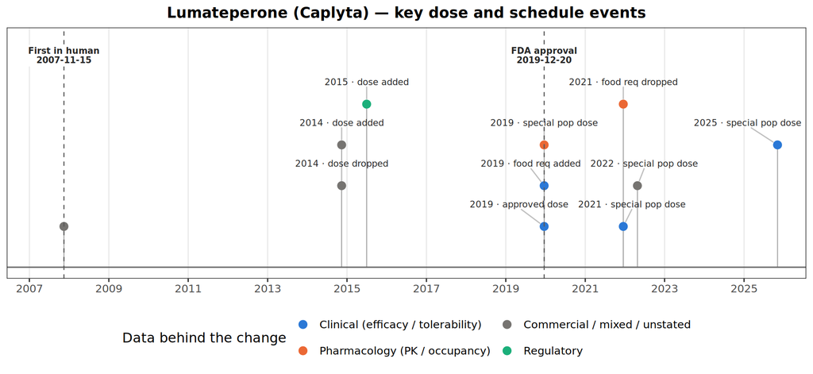

Lumateperone — dated dose and schedule changes, colored by the data family behind each change; dashed lines mark the first-in-human anchor (or the earliest dated human-program milestone, labelled as such) and the first FDA approval. The figure shows dated changes of the key types only; routine range-tested rows, label clarifications, and any change the record leaves undated are omitted here but are listed in full in the table below, which is why the table carries more rows than the figure has points.

**Anchors.** First in human: 2007-11-15 — IND 079690 first clinical trial (open-label receptor-occupancy study) allowed to proceed 2007-11-15. First FDA approval: 2019-12-20 — Single approved dose 42 mg QD, no titration; single 42 mg strength marketed.

Dated dose and schedule changes — Lumateperone (Caplyta).

| Date | Event | Attribute | From | To | Driver | Detail |
| --- | --- | --- | --- | --- | --- | --- |
| 2007-11-15 | range tested | Development start dose strategy | — | Phase 1 program opened with an occupancy-first strategy; across Phase 1 (Studies 002/006/009/016) single+repeat oral doses 5-140 mg/day and a 40 µg IV microdose were tested | Occupancy | IND 079690 (submitted 2007-10-15) opened with an open-label receptor-occupancy study as the first clinical trial; FDA allowed it to proceed 2007-11-15 - dose selection was anchored to PET occupancy ra… |
| 2007-11-15 | first in human | First clinical study | — | IND 079690 first clinical trial (open-label receptor-occupancy study) allowed to proceed 2007-11-15 | Not stated | First-in-human anchor. The FDA review identifies the IND-opening study only as an open-label PET occupancy study; the first dosed subject date is not stated, so the IND clearance date is used at day p… |
| 2014-06 | range tested | Phase 3 dose range advice | — | FDA asked for a trial of at least 6 weeks and stressed including different doses in Phase 3 to characterize the full dose-response, integrating dose-response and receptor-occupancy analyses | Regulatory | June 2014 FDA meeting on Phase 3 plans: Agency suggested integrating dose-response and occupancy analyses to select a broader range of doses for Phase 3 (Study 005 had tested only 42/84 mg). |
| 2014-11-13 | dose dropped | Tested dose 84mg | 84 mg QD (tested in Study 005) | 84 mg never carried into Phase 3 | Mixed | In Study 005, 84 mg showed no PANSS separation from placebo while 42 mg did; 84 mg had more sedation-like events and poorer-attention signals (U-shaped dose-response per OCP). Drop is first visible wh… |
| 2014-11-13 | dose added | Tested dose 28mg | 42 mg only efficacious dose known | 28 mg QD added alongside 42 mg in Study 301 | Mixed | Lower dose added per FDA’s 2014 advice to characterize dose-response; 28 mg had shown ~40% peak / 29% average striatal D2 occupancy in earlier PET, predicted to be in the efficacious range. Date = Stu… |
| 2015 | dose added | Tested dose 14mg | — | 14 mg QD added alongside 42 mg in Study 302 | Regulatory | 14 mg selected to probe a dose lower than 42 mg while Study 301 (28 mg) was still ongoing - continued lower-range exploration per FDA dose-response advice. Neither 14 nor 42 mg separated from placebo … |
| 2019-12-20 | approval | Approved dose | 42/84 mg (Ph2) then 14/28/42 mg (Ph3) tested | Single approved dose 42 mg QD, no titration; single 42 mg strength marketed | Efficacy / dose-response | Only 42 mg showed efficacy (Studies 005 and 301; 14/28/84 mg all failed; Study 302 failed entirely with a robust placebo response). A July 31 2019 AdCom - scheduled over NONCLINICAL toxicity questions… |
| 2019-12-20 | food req added | Food requirement | No food requirement during Phase 1 fasted/fed testing | Label: administer 42 mg once daily WITH food | Tolerability | Food lowered Cmax ~33% (AUC ~unchanged); with GI adverse events more frequent at higher doses, OCP reasoned lower Cmax with food may mean fewer GI effects, and pivotal trials had dosed with food per p… |
| 2019-12-20 | special pop dose | Special population access | OCP analyses supported 21 mg (moderate/severe hepatic impairment; moderate CYP3A4 inhibitors) and 10.5 mg (strong CYP3A4 inhibitors) | Label instead says AVOID use in moderate/severe hepatic impairment and with moderate/strong CYP3A4 inhibitors or any CYP3A4 inducer - no lower strengths existed; PMC 3760-8 requires developing 10.5 an… | PK / metabolite | Hepatic impairment raised AUC up to ~2.4-fold, itraconazole ~4-fold, diltiazem ~2-fold, rifampin cut AUC to 2.1%; with 42 mg the only strength, dose adjustment was impossible, so avoid-use language su… |
| 2021-12-17 | food req dropped | Food requirement | 42 mg once daily with food | 42 mg once daily with or without food | PK / metabolite | s005/s006 review: food effect similar and modest for capsule and OE tablet (Cmax -25 to -33%, AUC0-inf +9 to +19%) against 68-97% CV steady-state PK variability; bipolar trials had dosed in the evenin… |
| 2021-12-17 | special pop dose | Indication extension | Schizophrenia only | Bipolar depression (bipolar I/II, monotherapy and adjunct) added at the SAME 42 mg QD dose, no titration | Efficacy / dose-response | One-line other-indication event per scope: Studies ITI-007-404 (monotherapy) and -402 (adjunct) each positive on MADRS at 42 mg; no new therapeutic dose introduced. |
| 2022-04-26 | special pop dose | Strengths and special pop dosing | Avoid use (moderate/severe hepatic impairment; moderate/strong CYP3A4 inhibitors); 42 mg sole strength | New strengths 10.5 and 21 mg: 10.5 mg with strong CYP3A4 inhibitors; 21 mg with moderate CYP3A4 inhibitors; 21 mg in Child-Pugh B/C. NOT new therapeutic doses - 42 mg remains the only schizophrenia do… | Mixed | Fulfills PMC 3760-8 from the 2019 approval letter (develop 10.5/21 mg strengths); doses per the original hepatic-impairment (ITI-007-010) and CYP3A4-inhibitor (ITI-007-012) exposure matching. Approval… |
| 2025-11-05 | special pop dose | Indication extension | Schizophrenia + bipolar depression | Adjunctive therapy to antidepressants for MDD added (s016), same 42 mg QD | Efficacy / dose-response | One-line other-indication event per scope; no change to schizophrenia dosing. |
| 2026-04-24 | label clarification | Maintenance evidence | Approval based on 4-6-week acute trials only; maintenance question open (PMC 3760-7) | Section 14 adds Study 3 (NCT04959032): randomized-withdrawal maintenance, 42 mg significantly delayed relapse vs placebo; dose and no-titration recommendation unchanged | Efficacy / dose-response | s017 fulfills PMC 3760-7 (placebo-controlled randomized-withdrawal maintenance study in schizophrenia, required at 2019 approval; timetable completion 12/2023). Still no titration and no second therap… |
| — | range tested | Phase 2 dose arms | Phase 1 range 5-140 mg/day | 42 mg and 84 mg QD fixed, no titration (Study ITI-007-005) | Mixed | 42/84 mg chosen from tolerability in Study ITI-007-002 plus projected striatal D2 occupancy of ~50% (42 mg) and ~70% (84 mg) from earlier healthy-volunteer PET at lower doses; conduct dates not stated… |

The dose-related question each key study answered — Lumateperone (Caplyta).

| Phase | Study type | Study | Dosing design | Question the study answered |
| --- | --- | --- | --- | --- |
| 1 | First-in-human (SAD/MAD) | ITI-007-002 | — | What single/repeat doses are safe and tolerable, and what is the PK, to support Phase 2 dose selection? |
| 1 | Thorough QT | ITI-007-017 | Fixed | Does lumateperone prolong QTc at therapeutic (42 mg) or supratherapeutic (126 mg) doses? |
| 1 | Food effect | ITI-007-019 | Single dose | Does food change lumateperone exposure from the commercial capsule (basis of the with-food instruction and its later removal)? |
| 1 | Food effect | ITI-007-031 | Single dose | Does food affect the over-encapsulated tablet (bipolar-trial formulation) the same way as the capsule - evidence behind dropping the food requirement? |
| 1 | PET receptor occupancy | — | — | Which dose saturates cortical 5-HT2A while keeping striatal D2 occupancy low - the occupancy anchor for Phase 2 dose selection? |
| 1 | PET receptor occupancy | — | Fixed | What striatal D2 occupancy does the therapeutic 42 mg dose actually produce at steady state in patients? |
| 2 | Dose-ranging | ITI-007-005 | Fixed | Does lumateperone show antipsychotic efficacy, and at which of two occupancy-guided doses (42 vs 84 mg)? |
| 3 | Pivotal efficacy | ITI-007-301 | Fixed | Does 42 mg confirm efficacy, and does a lower occupancy-plausible dose (28 mg, ~40% peak D2RO) also work? |
| 3 | Pivotal efficacy | ITI-007-302 | Fixed | Does 42 mg replicate at 6 weeks, and is 14 mg a minimally effective dose? |
| 3b/4 | Maintenance / withdrawal | — | Fixed | Does 42 mg prevent relapse on longer-term treatment (the maintenance question left open at approval)? |

### 4.3.5 Ulotaront (failure contrast)

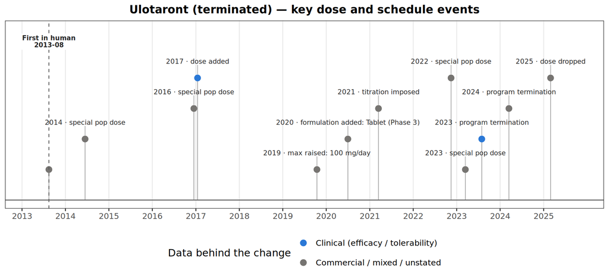

Ulotaront — dated dose and schedule changes, colored by the data family behind each change; dashed lines mark the first-in-human anchor (or the earliest dated human-program milestone, labelled as such) and the first FDA approval. The figure shows dated changes of the key types only; routine range-tested rows, label clarifications, and any change the record leaves undated are omitted here but are listed in full in the table below, which is why the table carries more rows than the figure has points.

**Anchors.** First in human: 2013-08 (month) — SEP361-105 single-ascending-dose study (25-150 mg) in adults with schizophrenia, started 2013-08 (NCT01940159). First FDA approval: — (not approved).

Dated dose and schedule changes — Ulotaront (terminated).

| Date | Event | Attribute | From | To | Driver | Detail |
| --- | --- | --- | --- | --- | --- | --- |
| 2013-08 | first in human | First clinical study | — | SEP361-105 single-ascending-dose study (25-150 mg) in adults with schizophrenia, started 2013-08 (NCT01940159) | Not stated | First-in-human anchor, at the month precision the registry gives. Ulotaront has no FDA package. |
| 2014-06 | special pop dose | Other indication | — | Narcolepsy-cataplexy Phase 1b crossover: ulotaront 25 and 50 mg/day; reduced cataplexy but no PSG/ESS improvement (SEP361-108) | Not stated | Early exploration of a second indication at the low end of the dose range; one-line event per scope rule |
| 2014 | range tested | Dose range | — | Single doses 25-150 mg (schizophrenia patients; down to 5 mg across the Phase 1 pool incl. healthy volunteers); multiple doses up to 100 mg/day plus a 75 mg/day open-label arm | Tolerability | FIH SAD/MAD escalation (SEP361-105/-106, run in patients) defined the tolerated range; popPK later showed dose-proportional PK 10-100 mg and ~7 h effective half-life supporting once-daily dosing witho… |
| 2016-12 | range tested | Phase 2 dose range | Phase 1 tolerated range (multiple doses <=100 mg/day) | Flexible 50-75 mg/day, single arm (pivotal Phase 2, acute schizophrenia) | Not stated | No fixed-dose Phase 2 dose-ranging study was conducted; the program went directly to one flexibly-dosed 50/75 mg/day arm; published dose-selection rationale absent (the REM-sleep PK/PD marker publicat… |
| 2016-12 | special pop dose | Other indication | — | Parkinson’s disease psychosis pilot: flexible 25/50/75 mg/day, all patients starting at 25 mg (SEP361-203) | Not stated | Lower starting dose in the elderly PD-psychosis population; one-line event per scope rule |
| 2017-01 | dose added | Long term dose floor | 50-75 mg/day (acute Phase 2 range) | 25-75 mg/day (26-week open-label extension) | Tolerability | The extension (SEP361-202) added a 25 mg/day down-titration option for long-term tolerability management; long-term dose range reported as 25-75 mg/day |
| 2019-09 | range tested | Phase 3 dose range | Flexible 50-75 mg/day (Phase 2) | Fixed 50, 75, and 100 mg/day across two studies: DIAMOND 1 (50/75) and DIAMOND 2 (75/100) | Not stated | Fixed-dose registration program launched ~4 months after FDA Breakthrough Therapy designation (2019-05-10, granted on flexible-dose Phase 2 + extension data); sponsors published no rationale for the f… |
| 2019-10 | max raised | Max daily dose | 75 mg/day | 100 mg/day | Not stated | 100 mg/day introduced in DIAMOND 2 and the Phase 3 open-label studies with no Phase 2 efficacy or tolerability exposure at that dose; popPK showed dose-proportionality 10-100 mg; the TQT and DDI studi… |
| 2020 | formulation added | Formulation | Capsule (Phase 1-2) | Tablet (Phase 3) | Not stated | Tablet introduced for Phase 3 (TQT study used tablets by mid-2020); bioequivalence tablet-vs-capsule demonstrated at 25 mg and no food effect for the tablet, so no food requirement was ever imposed |
| 2021-03 | titration imposed | Titration | Start at assigned fixed dose | 3-day 50 mg/day lead-in before 75 mg/day (DA801201); later codified as 50 (Days 1-3) then 75 (Days 4-7) then optional 100 mg/day (SEP361-308, 2022) and as a 50-75-100 default schedule (Japan long-term… | Not stated | Up-titration schedules appear in the Japan/Asia and switch studies from 2021 onward; rationale unpublished (pattern consistent with managing early tolerability, e.g. somnolence) |
| 2022-11 | special pop dose | Other indication | — | Adjunctive MDD Phase 2/3 started (flexible-dose, n=929, Otsuka/Sunovion; completed 2025-11; topline not found as of 2026-08-13) | Not stated | Indication broadening that pre-dated the schizophrenia failure; one-line event per scope rule |
| 2023-03 | special pop dose | Other indication | — | GAD Phase 2/3 started (flexible-dose, n=434, completed 2025-09); follow-on FIXED-dose GAD Phase 3 (50/75 mg/day) started 2026-07 | Not stated | GAD program advanced to a fixed-dose Phase 3 in 2026, implying an encouraging flexible-dose Phase 2/3; one-line event per scope rule |
| 2023-07-31 | program termination | US/Japan schizophrenia Phase 3 program | DIAMOND fixed-dose registration program ongoing | Sumitomo-led schizophrenia development halted after DIAMOND 1 and DIAMOND 2 both missed their primary endpoints | Efficacy / dose-response | DIAMOND 1 PANSS LS-mean change: 50 mg -16.9, 75 mg -19.6 vs placebo -19.3; DIAMOND 2: 75 mg -16.4, 100 mg -18.1 vs placebo -14.3. Sponsors attributed the misses to a large (COVID-era) placebo response… |
| 2024-03-15 | program termination | Sponsor | Sumitomo Pharma/SMPA + Otsuka worldwide co-development (agreement of 2021-09-30) | Otsuka holds exclusive worldwide rights to develop, manufacture, and commercialize ulotaront for all indications; Sumitomo exits active development | Commercial | Sumitomo cited difficulty generating revenue within its business-plan period and a strategic pivot to oncology/regenerative medicine; Otsuka fully covers study costs from January 2024; Sumitomo receiv… |
| 2025-02-28 | range tested | Phase 3 dose range restart | Schizophrenia program halted (2023-07) | Fixed 75 or 100 mg/day; new 6-week acute Phase 3 under Otsuka (NCT06894212, protocol 382-201-00035, n~522), plus Japan long-term study at a 100 mg/day target dose (NCT07225712, 2025-12) | Not stated | Otsuka restarted the schizophrenia registration program with the two highest DIAMOND doses and an eligibility requirement of demonstrated response to previous antipsychotics; no published sponsor stat… |
| 2025-02-28 | dose dropped | Pivotal dose range | 50, 75, 100 mg/day (DIAMOND program) | 75, 100 mg/day (restart program) | Not stated | 50 mg/day not carried into the Otsuka restart; consistent with the DIAMOND numeric dose trend and with a 2025 dose-response meta-analysis finding greatest efficacy at 100 mg and concluding ‘higher ulo… |

The dose-related question each key study answered — Ulotaront (terminated).

| Phase | Study type | Study | Dosing design | Question the study answered |
| --- | --- | --- | --- | --- |
| 1 | First-in-human (SAD/MAD) | SEP361-105 | Dose escalation | What single oral doses of ulotaront (25-150 mg) are safe and tolerated in adults with schizophrenia? |
| 1 | First-in-human (SAD/MAD) | SEP361-106 | Dose escalation | What multiple daily doses (up to 100 mg/day) are tolerated and what is the multiple-dose PK in adults with schizophrenia? |
| 1 | Thorough QT | SEP361-114 | Single dose | Does supratherapeutic ulotaront (150 mg, covering worst-case exposure at the highest anticipated clinical dose of 100 mg/day in CYP2D6 poor metabolizers) prolong QTc? |
| 1 | Food effect | — | Single dose | Does food affect the PK of the ulotaront tablet (i.e., is a food requirement needed)? |
| 1b | PET receptor occupancy | SEP361-118 | Flexible | Does ulotaront reduce striatal dopamine synthesis capacity ([18F]-DOPA PET Ki) - an indirect target-engagement marker, given that no TAAR1 occupancy tracer exists? |
| 2 | Pivotal efficacy | SEP361-201 | Flexible | Is ulotaront efficacious in acute schizophrenia at flexible 50-75 mg/day over 4 weeks (PANSS total)? |
| 3 | Pivotal efficacy | SEP361-301 | Fixed | Which fixed dose (50 or 75 mg/day) is efficacious in acute schizophrenia over 6 weeks? |
| 3 | Pivotal efficacy | SEP361-302 | Fixed | Is a higher fixed dose (100 mg/day, never tested in Phase 2) more efficacious than 75 mg/day in acute schizophrenia? |
| 3 | Pivotal efficacy | DA801201 | Fixed | Are fixed 50 or 75 mg/day efficacious in acutely psychotic patients in Japan/Asia? |
| 3 | Pivotal efficacy | 382-201-00035 | Fixed | Can fixed 75 or 100 mg/day demonstrate efficacy in a re-run 6-week acute trial, after the DIAMOND program failed amid high placebo response? |

### 4.3.6 Xanomeline–trospium (index case)

The transcription case. The newest approval (September 2024) answers the flexible-dosing question by *codifying* it: the EMERGENT trials titrated xanomeline/trospium 50/20 mg BID → 100/20 mg BID (day 3) → optional 125/30 mg BID (day 8) — forced titration with an optional top step, coded as flexible in the tables here because that last step was a tolerability decision — and the label reproduces that schedule verbatim, including the fasting window (1 h before / 2 h after meals) and a geriatric cap at 100/20. At the end-of-Phase-2 meeting the FDA requested a fixed-dose study; the sponsor declined, and exposure-response analyses later found efficacy flat between the two upper strengths — the dose question was closed by argument, not by a dedicated trial. That argument is worth reading against the distinction drawn in the Background: exposure in a forced-titration trial is generated in part by the escalation decision, so a flat exposure-response relationship there cannot be cleanly separated from titration having equalized response across patients. The conclusion may well be right; the design cannot establish it the way a fixed-dose comparison would. With no muscarinic PET tracer, the dose rationale traces to the legacy Lilly xanomeline Alzheimer’s trials (75–225 mg/day) and tolerability. Four label versions on, nothing about the dosing section has changed.

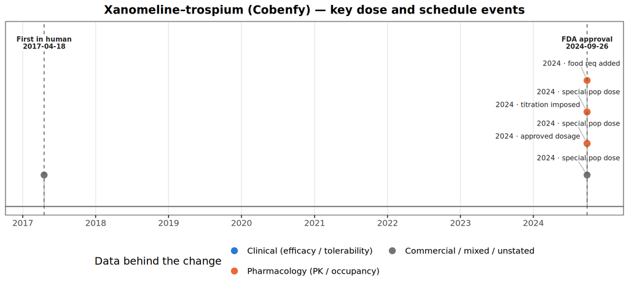

Xanomeline–trospium — dated dose and schedule changes, colored by the data family behind each change; dashed lines mark the first-in-human anchor (or the earliest dated human-program milestone, labelled as such) and the first FDA approval. The figure shows dated changes of the key types only; routine range-tested rows, label clarifications, and any change the record leaves undated are omitted here but are listed in full in the table below, which is why the table carries more rows than the figure has points.

**Anchors.** First in human: 2017-04-18 — KAR-002, first Karuna Phase 1 of the xanomeline-trospium combination, started 2017-04-18. First FDA approval: 2024-09-26 — NDA 216158 approved: 50/20 mg BID >=2 days, then 100/20 mg BID >=5 days, optional increase to 125/30 mg BID by tolerability/response; max 125/30 mg BID.

Dated dose and schedule changes — Xanomeline–trospium (Cobenfy).

| Date | Event | Attribute | From | To | Driver | Detail |
| --- | --- | --- | --- | --- | --- | --- |
| 1997 | range tested | Dose range | — | xanomeline monotherapy 75/150/225 mg/day (25/50/75 mg TID), Alzheimer’s disease (Lilly) | Mixed | Legacy Lilly AD trial (Bodick 1997, n=343): efficacy on ADAS-Cog and CIBIC at 225 mg/day, but GI/cholinergic AEs drove high discontinuation and the program was stopped - the tolerability ceiling the l… |
| 2017-04-18 | first in human | First clinical study | — | KAR-002, first Karuna Phase 1 of the xanomeline-trospium combination, started 2017-04-18 | Not stated | First-in-human anchor for the combination. Xanomeline alone was first given to humans in the 1990s (Lilly Alzheimer program); the combination is the program reconstructed here. |
| 2020-05-19 | range tested | Dosing strategy | FDA-recommended fixed-dose study to characterize dose-response | flexible-dose titration retained for KAR-007/KAR-009; no fixed-dose study ever conducted | Not stated | At EOP2 (2020-05-19) and again 2021-04-21 the Division expressed concern about an NDA with only flexible-dose studies; the applicant proceeded flexible-only, precluding direct dose-response evaluation… |
| 2024-09-26 | approval | Approved dosage | — | NDA 216158 approved: 50/20 mg BID >=2 days, then 100/20 mg BID >=5 days, optional increase to 125/30 mg BID by tolerability/response; max 125/30 mg BID | Mixed | First-in-class M1/M4 agonist approval; the label’s dosage section transcribes the EMERGENT flexible-dose titration verbatim (both maintenance doses effective; no AdCom held). |
| 2024-09-26 | titration imposed | Titration | (new approval) | mandatory BID titration: start 50/20 mg BID for at least 2 days; increase to 100/20 mg BID for at least 5 days; optional 125/30 mg BID - trospium escalates 20 -> 30 mg with the top step | Tolerability | Gradual titration mitigates initiation cholinergic AEs; the scheme is the EMERGENT trial design (50/20 d1-2, 100/20 d3-7, day-8 escalation default unless AEs) carried into labeling. |
| 2024-09-26 | food req added | Food requirement | — | administer at least 1 hour before or at least 2 hours after a meal | PK / metabolite | KAR-055 food-effect study: food reduced trospium AUC ~71-76% and Cmax ~87-88% (xanomeline largely unaffected); fasting window preserves the peripheral anticholinergic shield that makes xanomeline tole… |
| 2024-09-26 | special pop dose | Max daily dose (geriatric) | adult max 125/30 mg BID | geriatric max 100/20 mg BID with slower titration considered | Mixed | No subjects >65 y at marketed doses in the efficacy trials; KAR-030 elderly study showed poor tolerability at higher doses; popPK: trospium AUC +60%, Cmax +36% in >=65 y; enhanced anticholinergic sens… |
| 2024-09-26 | special pop dose | Renal dosing | — | mild renal impairment: no adjustment; moderate/severe renal impairment: not recommended | PK / metabolite | KAR-050: xanomeline and trospium exposures ~2x (mild) to ~2.4-3x (moderate/severe) vs normal; ~73 mild-RI subjects in the efficacy trials tolerated the full regimen, supporting no adjustment for mild … |
| 2024-09-26 | special pop dose | Hepatic dosing | — | mild hepatic impairment: not recommended; moderate/severe hepatic impairment: contraindicated | PK / metabolite | KAR-051/KAR-054: xanomeline exposure 2.8x in mild and ~7x in moderate hepatic impairment (trospium unaffected); moderate cohort tolerated dosing poorly (6/9 stopped early). |
| 2026-01-16 | label clarification | Dosing section | Dosage and Administration, SPL v1/v3 | Dosage and Administration unchanged (byte-identical) through SPL v4 (eff 2026-01-16) and v5 (pub 2026-06-11) | Not stated | Post-approval SPL revisions are editorial only (sponsor-name hyphenation, markup); Section 2 dosing text is byte-identical across all four published versions (v1, v3, v4, v5) - zero post-approval dosi… |
| — | range tested | Dose range | legacy xanomeline 75 mg TID (225 mg/day) exposure reference | KarXT BID range tested 100/20 to 150/40 mg; MTD = 125/40 mg BID; 150 mg xanomeline BID abandoned as intolerable | Tolerability | KAR-003 adaptive dose-ranging (after the 2017-04-19 clinical hold terminated KAR-002 and its replacement protocol was cleared 2017-08-03): 150 mg BID too high with either trospium dose; 125/40 BID com… |
| — | range tested | Dose arms | phase 1 MTD 125/40 mg BID | efficacy doses 100/20 and 125/30 mg BID reached by forced titration from 50/20 mg BID (flexible design, target 125/30) | Mixed | Doses for KAR-004/007/009 selected on PK similarity of 100/20 BID to legacy 75 mg TID (reported to improve psychosis/cognition in AD), BID adherence advantage over TID, and the 125/40 BID MTD; top-dos… |

The dose-related question each key study answered — Xanomeline–trospium (Cobenfy).

| Phase | Study type | Study | Dosing design | Question the study answered |
| --- | --- | --- | --- | --- |
| 1 | First-in-human (SAD/MAD) | KAR-002 | — | First Karuna phase 1 of the KarXT combination (safety/tolerability); terminated before completion. |
| 1 | Dose-ranging | KAR-003 | Dose escalation | What is the maximum tolerated KarXT BID dose, and which KarXT dose reproduces the exposure of legacy xanomeline 75 mg TID? |
| 1 | Thorough QT | KAR-053 | Forced titration | Does KarXT prolong QTc at therapeutic exposures, and are xanomeline/trospium PK dose-proportional between 100/20 and 125/30 mg BID? |
| 1 | Food effect | KAR-055 | Single dose | Does food change xanomeline/trospium bioavailability (the basis of the label fasting window)? |
| 2 | Pivotal efficacy | KAR-004 | Flexible | Does the titrated flexible-dose KarXT regimen (target 125/30 mg BID) beat placebo on PANSS total at week 5 (proof of concept in acute schizophrenia)? |
| 3 | Pivotal efficacy | KAR-007 | Flexible | Does the same flexible titration regimen replicate efficacy in a phase 3 acute inpatient population (primary substantial-evidence trial)? |
| 3 | Pivotal efficacy | KAR-009 | Flexible | Does the flexible titration regimen replicate efficacy in a second phase 3 trial including non-US sites (Ukraine)? |

## 4.4 Occupancy: the window that stopped mattering

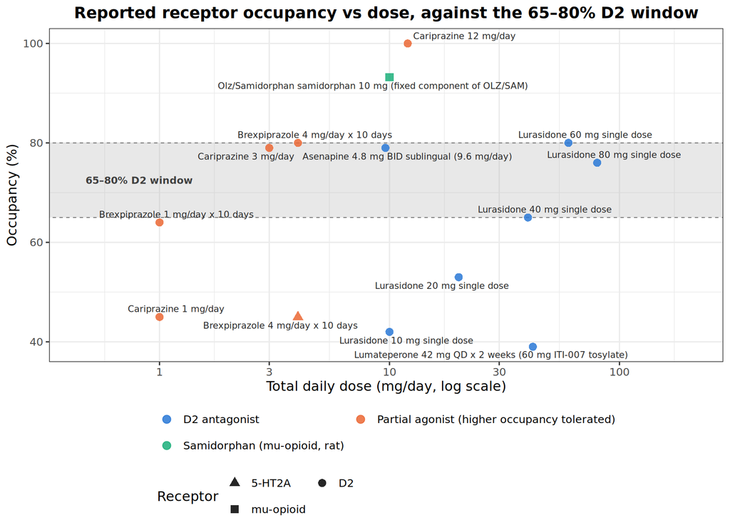

Reported receptor occupancy by dose (each point one reported dose-occupancy estimate), plotted against total daily dose. Point shape gives the receptor: the shaded 65–80% band is a **D2** threshold and applies only to the D2 points. The two exceptions are labelled by shape — the 45% brexpiprazole point is 5-HT2A (not D2, so it is not a low D2 occupancy at 4 mg), and the samidorphan point is mu-opioid occupancy in rat. Partial agonists tolerate near-saturating D2 occupancy. Lurasidone’s points are single-dose PET values, as their labels state; the rest are steady-state daily doses.

Current label range vs the 65–80% D2 occupancy window, per program. Occupancy is quoted as each source states it — point estimate with the reported regional range or SD where given — so precision varies with the source, and a value cited elsewhere in this report from the FDA review rather than the publication may carry an extra decimal. The verdict is derived from the point estimates at doses inside the label range only: doses tested below the approved floor cannot license a claim about the approved range. “Top of the range not anchored” means no dose near the label maximum has a reported occupancy value. Partial agonists are not judged against the window at all, since they tolerate near-saturating occupancy.

| Program | Current label range | Reported D2 occupancy, as the source states it | Verdict vs the 65–80% D2 window |
| --- | --- | --- | --- |
| Asenapine (Saphris) | 10–20 mg/day | mean 79% at 4.8 mg BID sublingual (9.6 mg/day) · [11C]raclopride · not stated in review | Within the window; top of the range not anchored |
| Brexpiprazole (Rexulti) | 2–4 mg/day | 64 ± 8% (striatal) at 1 mg/day x 10 days; 80 ± 12% (striatal) at 4 mg/day x 10 days · [11C]-(+)-PHNO · patients with schizophrenia (N=12 across cohorts) | Partial agonist — window logic differs |
| Cariprazine (Vraylar) | 1.5–6 mg/day | 45% (14-64%) at 1 mg/day; 79% (68-88%) at 3 mg/day; ~100% D2 and D3 at 12 mg/day · [11C]-(+)-PHNO · patients with schizophrenia (3/cohort) | Partial agonist — window logic differs |
| Lumateperone (Caplyta) | 42 mg/day | 39% (± 12% SD; median 39% (n=6, 1 h scans)) at 42 mg QD x 2 weeks (60 mg ITI-007 tosylate) · [11C]raclopride · patients with schizophrenia (N=10) | Far below the window — approved anyway |
| Lurasidone (Latuda) | 40–160 mg/day | 42% (41-43% across regions) at 10 mg single dose; 53% (51-55% across regions) at 20 mg single dose; 65% (63-67% across regions) at 40 mg single dose; 80% (77-84% across regions) at 60 mg single dose; … | Straddles the window; top of the range not anchored |
| Olanzapine/Samidorphan (Lybalvi) | 5–20 mg/day (olanzapine component) | 43-80% (10-20 mg/day: 71-80%) at olanzapine 5-20 mg/day; 83-88% at olanzapine 30-40 mg/day · [11C]raclopride · patients with schizophrenia (N=12 randomized + 3 high-dose); patients with schizophrenia … | Reported as a range only — no point estimate to place |
| Iloperidone (Fanapt) | 12–24 mg/day | — | Indeterminate — no human dose–occupancy study identified |
| Ulotaront (terminated) | — (terminated, never approved) | — | Not applicable — non-dopaminergic target, no tracer existed |
| Xanomeline–trospium (Cobenfy) | 100–250 mg/day (xanomeline component) | — | Not applicable — non-dopaminergic target, no tracer existed |

Two limits on reading the figure across drugs. The points pool single-dose peak occupancy in healthy volunteers (lurasidone, [11C]raclopride, four per cohort — hence the non-monotone 60 versus 80 mg values) with steady-state patient values, and the cariprazine and brexpiprazole points come from a D3-preferring tracer ([11C]-(+)-PHNO) whose D2 component is reported separately by region. The window is a guide to the pattern, not a common scale.

The window’s authority declines across the cohort’s fifteen years. Lurasidone used it operationally (a 20 mg dose was dropped at 51–54.8% occupancy, together with its Phase 2 efficacy data). The partial agonists redefined it: cariprazine reached ~100% D2/D3 in a small PET cohort at 12 mg/day — twice its approved maximum — without the acute EPS a full antagonist would produce at that occupancy, while at the approved 3 mg/day it sits at ~79%. Lumateperone was approved *at 39%* striatal D2 — but that was the design, not a defeat of the tracer: its own PET shows cortical 5-HT2A occupancy above 80% at a dose giving ~12% D2, so 42 mg was chosen against a different receptor. And the two newest mechanisms ran with no occupancy measurement at all: no TAAR1 or M1/M4 tracer existed during development.

The efficacy side tells a similarly unsettled story, though on much weaker evidence. A published spline dose-response meta-analysis (Leucht 2020) reports near-maximal effective doses (ED95) for 3 of the 6 fully reconstructed programs; the other 3 post-date its search window or never reached a dose-response estimate. Where values exist they point in different directions relative to the approved maximum: cariprazine’s ED95 (7.6 mg/day) sits *above* its 6 mg/day maximum, lurasidone’s (147 mg/day) just below a 160 mg/day maximum whose curve never plateaued, and iloperidone’s (20.1 mg/day) inside its approved 12–24 mg/day range. These are point estimates carried without uncertainty from a single external secondary source, not from the regulatory record this study reconstructs, and cariprazine’s value was read from search extracts of the full text rather than the abstract. They are annotation, not a result of this study. Taken only that far, they support the same reading as the occupancy points: neither the tracer nor the efficacy curve settled these dose ranges on its own.

# 5 Discussion

**Flexible dosing defers the dose question; someone eventually pays.** Ulotaront is the clean experiment: a positive flexible-dose Phase 2, no dose-ranging, then two failed fixed-dose Phase 3 trials including an untested dose. The 2025 restart — at the top of the range, with the bottom dropped — is the program’s own admission of where the information gap sat.

**Regulators know this, and push back at end-of-Phase-2.** The two end-of-Phase-2 (EOP2) verdicts in this cohort went opposite ways: lurasidone’s flexible Phase 3 proposal was rejected outright (fixed 40/80/120 imposed), while xanomeline–trospium’s sponsor declined the requested fixed-dose study and prevailed with exposure-response arguments. The difference: KarXT arrived with a forced-titration design where the flexible corridor *was* the intended label, making the trial-to-label transcription argument available.

**Titration is a dose decision expressed as a schedule.** Iloperidone’s range is inseparable from its mandatory week-long climb; cariprazine’s “no titration required” label conceals a metabolite that titrates itself over six weeks; xanomeline–trospium’s label is *only* titration. Where a program’s schedule is doing the dose’s work, a Phase 2 that varies the schedule and not the dose has not tested the dose.

**Flexible dosing is the right design when the regimen is the product — and that is a narrow condition.** The cohort contains legitimate cases, and they share a feature. Iloperidone *had* to be titrated: α1-adrenergic orthostasis makes a fixed high-dose arm a syncope study rather than an efficacy study, so forced titration protected the trial’s ability to detect an effect at all. Xanomeline–trospium’s corridor was the intended label, so a trial of the corridor estimated the quantity that would be marketed. In both, the estimand delivered by a flexible design — the effect of *this titration strategy* — is the estimand the program actually needed. The failure mode is different: using a flexible Phase 2 as a *cheap substitute* for dose-finding, then treating a positive result as dose selection. A positive flexible Phase 2 licenses the molecule, not the dose, and the record here shows the difference is not academic.

**Caps below demonstrated efficacy are common — and asymmetric.** Lurasidone (80 vs 120), cariprazine (6 vs 9), and lumateperone (42 as sole survivor) were all approved below or at the bottom of their demonstrated efficacy ranges, trading ceiling for tolerability. Only lurasidone won its range back — and the reason it could is that the 160 mg dose had already been tested in a head-to-head Phase 3 comparison completed before approval. It recovered a dose it had *studied and been refused*, which took eighteen months of argument but no new trial. The asymmetry matters for Phase 2 planning: a dose that was tested can be re-argued, while a dose never tested has nothing to re-argue from, as cariprazine’s still-open lower-maintenance-dose question shows.

**The occupancy anchor is gone; nothing has replaced it.** The 65–80% window organized the D2 era’s dose decisions. The cohort’s newest three approvals (lumateperone, olanzapine/samidorphan’s samidorphan component, xanomeline–trospium) and its failure (ulotaront) were all dosed without a usable occupancy target. Phase 2 dose-ranging is again the only place the dose-response question can be answered — which makes deferring it to a flexible design costlier than it was when a PET study could arbitrate.

## 5.1 What this implies for a Phase 2 design

The cohort does not support a blanket verdict against flexible dosing; it supports a sequencing rule and a design hierarchy.

**Randomized parallel fixed-dose is what answers the question.** Three or more doses spanning a wide range — including one expected to be too low and one at the tolerability edge — against placebo, analyzed for *shape* rather than as pairwise comparisons. This is the long-standing regulatory position (ICH E4, which treats parallel fixed-dose designs as the primary source of dose-response information and notes that titration designs confound dose with time and with prognosis), and it is the design the FDA imposed on lurasidone at end-of-Phase-2 (fixed 40/80/120 in place of the sponsor’s flexible proposal), and it is the only design in this cohort that revealed a non-monotone picture: lumateperone’s 84 mg failed above the eventual dose and its 28 and 14 mg failed below, leaving one dose standing. No titration design would have shown that.

**When fixed dosing is untenable, randomize the algorithm rather than abandon randomization.** A randomized titration design — patients randomized to a titration *target* or *schedule*, not to an achieved dose — preserves a valid contrast under tolerability constraints that would make fixed high-dose arms uninformative. It is the design iloperidone’s pharmacology called for and the middle ground the cohort’s flexible Phase 2s skipped.

**Treat a positive flexible proof-of-concept as a go decision, not a dose decision.** If a flexible design is used for its power advantage on “is there a signal,” the program should budget a fixed-dose dose-ranging study before confirmatory trials. Substituting the former for the latter is precisely the step that preceded this cohort’s one clean failure.

**Plan the range you may later want to keep.** The asymmetry above is a planning constraint, not a footnote. The cohort’s one recovered dose was recovered because it had been *tested and refused*, leaving evidence to re-argue; the doses that were simply never given have no such route, and none of them came back. Testing a dose you may not register is therefore cheap insurance against a cap you cannot later lift.

**Ask whether an individual optimum exists before designing for one.** Where no short-horizon predictor of who needs a higher dose is available — the situation in acute schizophrenia — a titration algorithm cannot deliver individualization and is doing something else: managing tolerability, or deferring a decision. Naming which of the two is intended clarifies whether flexible dosing is the right instrument.

## 5.2 Limitations

- **Inferential reach is limited by design, and the discussion should be read accordingly.** Six programs is a description of a class, not a sample supporting estimation, and two of the six — ulotaront and xanomeline–trospium — were *chosen* rather than selected by the criterion, because they illustrate the extremes of the flexible-dosing question. The discussion’s first two arguments rest most heavily on exactly those two cases, which is selection on the outcome of interest. The four programs that met the criterion carry the arguments about narrowing, caps below efficacy, and the occupancy anchor; the flexible-dosing arguments should be read as a mechanism illustrated by well-documented cases, not as a rate. The two end-of-Phase-2 verdicts, in particular, are two observations that went opposite ways.
- The record shows *stated* rationale. FDA reviews and labels document what regulators and sponsors wrote down; internal decision-making beyond that is invisible, and “driver” assignments inherit that limit.
- **The RQ2 counts are conditional on one classification.** Every study is forced into exactly one question by a single deterministic map, written once and not recoded by an independent rater, and 25 post-approval events are classified the same way. Grouping decisions inside that map move the headline directly — separating disposition-characterization and food-effect studies from dose-adjustment ones is what makes the dose-adjustment class 35 studies rather than 60. The ordering is robust to that choice; the exact ratio is not. A residual 23 studies fall in *other / unclassified*: six lumateperone Phase 1 studies whose identity the FDA review does not describe, six pharmacodynamic-marker studies (pharmaco-EEG, fMRI, REM sleep, gastric emptying, ambulatory blood pressure) that engage the target without posing a dose question, two adjunctive-use trials, and a handful of switching, withdrawal and metabolic studies.
- Ulotaront’s reconstruction rests on the registry, publications, and press releases — there is no FDA package for a failed program, so its study list is not enumeration-complete (its unregistered Phase 1 studies are known only in aggregate).
- Study conduct dates for the approved programs’ early studies are sparse: FDA reviews rarely state them, and registry dates were deliberately not used (to keep the companion recall study clean). Event dates — the trajectory backbone — are documented; study-level chronology within phases is approximate.
- Facts seen only in search snippets (a minority; the per-fact verification level is recorded in the data) carry lower confidence than the majority whose primary document was read in full.

# 6 Reproducibility

The pipeline is deterministic and runs in four stages: per-program extractions are merged into the canonical tables (`01-extract/merge_staging.py`, Python) and checked (`01-extract/validate.R`); derived structures are built (`02-analyze/analyze.R`); figures, tables and every reported number are assembled into one bundle (`03-tlf/build_tlf.R`); and this report reads only that bundle (`04-report/report.Rmd`). No stochastic analysis step exists — label positioning in figures uses a fixed seed (20260813), which is the only random element. Numbers in the prose are inserted from the bundle rather than typed, so text and tables cannot drift apart. All extraction tables, the data dictionary, and stage scripts are version-controlled; the extraction data model and pre-specified cohort/criterion definitions were fixed before extraction began.

# 7 References

- International Council for Harmonisation. *E4: Dose-Response Information to Support Drug Registration.* 1994.
- Farde L, Nordström AL, Wiesel FA, et al. Positron emission tomographic analysis of central D1 and D2 dopamine receptor occupancy in patients treated with classical neuroleptics and clozapine. *Arch Gen Psychiatry.* 1992;49(7):538–544.
- Kapur S, Zipursky R, Jones C, Remington G, Houle S. Relationship between dopamine D2 occupancy, clinical response, and side effects: a double-blind PET study of first-episode schizophrenia. *Am J Psychiatry.* 2000;157(4):514–520.
- Bodick NC, et al. Effects of xanomeline, a selective muscarinic receptor agonist, on cognitive function and behavioral symptoms in Alzheimer disease. *Arch Neurol.* 1997;54(4):465–473.
- Koblan KS, et al. A non–D2-receptor-binding drug for the treatment of schizophrenia. *N Engl J Med.* 2020;382(16):1497–1506.
- Leucht S, et al. Dose-response meta-analysis of antipsychotic drugs for acute schizophrenia. *Am J Psychiatry.* 2020;177(4):342–353.
- Siafis S, et al. Antipsychotic dose, dopamine D2 receptor occupancy and extrapyramidal side-effects: a systematic review and dose-response meta-analysis. *Mol Psychiatry.* 2023;28:3267–3277.
- Vanover KE, et al. Dopamine D2 receptor occupancy of lumateperone (ITI-007): a positron emission tomography study in patients with schizophrenia. *Neuropsychopharmacology.* 2019;44(3):598–605.
- FDA approval packages ([Drugs@FDA](https://www.accessdata.fda.gov/scripts/cder/daf/)): NDA 022192 (iloperidone, 2009), NDA 200603 (lurasidone, 2010), NDA 204370 (cariprazine, 2015), NDA 209500 (lumateperone, 2019), NDA 216158 (xanomeline–trospium, 2024); archived label versions via DailyMed. The full per-fact source registry (146 sources with URLs, access dates, and verification levels) accompanies the extraction tables.

*Data & code availability: the extraction tables (studies, dose and schedule changes, sources, occupancy data), the data dictionary, and all stage scripts are maintained in a private project repository and are available from the author on request — this page is a rendered report, not a code distribution. The figures and tables above are built from those tables without manual editing. Every underlying fact is traceable without the repository: each row carries a `source_id` into the source registry, whose primary documents are the public FDA approval packages and label versions cited above. Companion study: registry recall of these trajectories.*